# Overview

FOCUS has implemented the periodicity of coils by using `IsSymmetric=2`. In principle, FOCUS optimized coils should conserve periodicity and stellarator symmetry if the target plasma has the properties. However, one might terminate the optimization before reaching the minimum by many reasons. In that sense, FOCUS optimized coils might not be strictly symmetric. A recent [presentation](https://wistell.engr.wisc.edu/wp-content/uploads/sites/741/2019/11/Coil-ripple-asymmetry-and-stability.pdf) by J. Schmitt indicates that finite asymmetry in coils may cause sizable differences in Boozer harmonics. Here, I imported the feature to conserve stellarator symmetry and change the implementation of periodicity.

## New implementation of periodicity

The plasma and coils are both periodic. In FOCUS calculations, we can only consider one period plasma, but we have to compute the magnetic field generated by all coils. If we have a case of `Nfp = N`, only coils in the first period $C_1$ will be treated as free variables. We have to calculate the magnetic field from it and its periodic coils on the point $P_1$. What FOCUS was doing is to

- Map the coils to the entire toroidal region and we have and its periodic coils $C_2, \cdots, C_N$. One can write down $C_i = C_1 \cdot M_{1,i}$, where $M_{1,i}$ is the rotation matrix from the 1st period to the $i$-th period.
- Sum the total magnetic field $B_{total} = \sum_{i=1}^N B(C_i, P_1)$.

There is another way to do this. One can

- Find the periodic points for $P_1$ on the plasma **in reverse direction** and mark them as $P_{-2}, \cdots, P_{-N}$. $P_{-i} = P_1 \cdot M_{1,-i}$.
- Then we have $B(C_i, P_1) = B(C_1, P_{-i}) \cdot M_{1,i}$, where $M_{1,i} \cdot M_{1,-i} = I$. The total magnetic field is now $B_{total} = \sum_{i=1}^N B(C_1, P_{-i})\cdot M_{1,i}$. Here, $P_{-1}=P_{1}$

By doing so, we save the computation to map the entire coil. Instead, we only need to find the (reversely-)periodic points and rotate the calculated magnetic field. It should be faster, but rigorous evaluations on the reduction of operations need further justifications.

## Stellarator symmetry

The stellarator symmetry means $R(-\theta, -\phi) = R(\theta, \phi)$ and $Z(-\theta, -\phi) = -Z(\theta, \phi)$. It has different meanings for scalars and vectors Dewar \& Hudson, \begin{align} S \{ f(r, \phi, z) \} & = f(r, -\phi, -z) , \\ S \{ \vec{F}(r, \phi, z) \} & = \vec{F}(-r, \phi, z) \ , \end{align} for arbitrary scalar function $f(r, \phi, z)$ and vector function $\vec{F}(r, \phi, z)$. Operator $S \{ \}$ means the stellarator symmetric operator. The operation on scalar functions in Cartesian coordinates can be interpreted as a rotation of $180^o$ over the $x$-axis, which has the following rotation matrix, $$ S_s = \begin{pmatrix} 1 & 0 & 0 \\ 0 & -1 & 0 \\ 0 & 0 & -1 \end{pmatrix} $$ while the operation on vector functions is $$ S_v = \begin{pmatrix} -1 & 0 & 0 \\ 0 & 1 & 0 \\ 0 & 0 & 1 \end{pmatrix} $$

FOCUS achieves the stellarator symmetry by doing the following operations,

- Find the symmetric point (of the evaluation point on the plasma) by $P_{S} = P \cdot S_s$.
- Calculate $B(C1, P_S)$ and find the symmetric vector $B(C_S, P_1) = B(C1, P_S) \cdot S_v$.

## Numerical details

Each coil will have a flag/property `symm` to indicate if the coil is periodic and/or stellarator symmetric. In `bfield.f90`, subroutine `bfield0` calculates the magnetic field $(tBx, tBy, tBz)$ generated at $(x, y, z)$ from *all the coils*. It is realized by the following loops.

```
! check if the coil is stellarator symmetric
  select case (coil(icoil)%symm)
  case ( 0 )
     cs  = 0
     Npc = 1
  case ( 1 )
     cs  = 0
     Npc = Nfp
  case ( 2)
     cs  = 1
     Npc = Nfp
  end select
  ! periodicity and stellarator symmetry
  do ip = 1, Npc
     do is = 0, cs
        ! find the point on plasma by rotating in reverse direction. + symmetric
        xx = ( x*cosnfp(ip) + y*sinnfp(ip) )
        yy = (-x*sinnfp(ip) + y*cosnfp(ip) ) * (-1)**is
        zz =  z * (-1)**is
        Bx = zero; By = zero; Bz = zero
        ... ! Biot-Savart law
        ! sum all the contributions
        tBx = tBx + (Bx*cosnfp(ip) - By*sinnfp(ip))*(-1)**is
        tBy = tBy + (By*cosnfp(ip) + Bx*sinnfp(ip))
        tBz = tBz +  Bz
     enddo
  enddo
```

## How to use

The periodicity (and stellarator symmetry) of the plasma boundary is controlled by `IsSymmetric`:

- 0: No periodicity or stellarator symmetry, Nzeta for $\zeta \in [0,2\pi]$.
- 1: Periodicity enforced, Nzeta for $\zeta \in [0,2\pi/N]$.
- 2: Both periodicity and stellarator symmetry enforced, Nzeta for $\zeta \in [0,\pi/N]$.

The number of periodicity, $N$, is determined by the plasma boundary file. By using `IsSymmetric = 1, 2`, we can reduce the required number for toroidal discretizations.

The coil (and stellarator symmetry) is controlled by `coil(icoil)%symm`. It has the following options.

- 0: No periodicity or stellarator symmetry.
- 1: Periodicity enforced (also applied to self-symmetric coils).
- 2: Both periodicity and stellarator symmetry enforced.

The `coil(icoil)%symm` is determined by

- case_init = -1 or 1: `coil(icoil)%symm = IsSymmetric`
- case_init = 0: `coil(icoil)%symm` is read from the `focus` file. There is an additional term in the file. Here is an example.

  ```
  # Total number of coils
             2
  #-----------------           1 ---------------------------
  #coil_type  coil_symm   coil_name
     1  2  Mod_001
  #Nseg        current         Ifree         Length         Lfree  target_length
   128  1.009791754928605E+06     1  8.670505423971651E+00     1  5.000000000000000E+00
  #NFcoil
  4
  #Fourier harmonics for coils ( xc; xs; yc; ys; zc; zs)
  3.060961066260489E+00  1.310212955829572E+00  1.071756836894852E-01 -1.120031822373825E-01 -1.520189821805770E-02
  0.000000000000000E+00  9.807643912272932E-03  4.065046339454286E-02  4.558754809350363E-02 -4.071238874284683E-03
  6.106710986192757E-01  2.443558277347133E-01 -5.149403228952965E-02 -2.671262885236908E-02  3.038448115689897E-02
  0.000000000000000E+00 -8.618896247479885E-02 -1.687662293413885E-01 -3.045505921769569E-03  3.878472675540980E-02
  2.542676666889435E-02 -7.560368186185138E-03 -1.412433048812937E-02 -5.744405973847212E-02 -2.717254366027788E-03
  0.000000000000000E+00  1.295879145275977E+00  8.161602814053179E-02 -1.281684450720204E-01 -7.864771290795677E-03
  #-----------3--backgound Bt Bz----------------
  #coil_type  coil_symm   coil_name
   3  0  bg_BtBz_01
  # Ic     I    Lc  Bz  (Ic control I; Lc control Bz)
  1    1.0E6  0  0.0
  ```

For background toroilda and vertical field (`coil(icoil)%type = 3`), `coil(icoil)%symm = 0` is assumed.

```python
cd /p/focus/source/working/examples/rotating_ellipse/
```

```
/p/focus/source/working/examples/rotating_ellipse
```

# Verifications and benchmark

I am going to use the rotating ellipse for verifying and benchmarking the new implementation. There are three branches envolved, master, develop, and symmetry. The master branch is currently at `v0.9.01` and the develop branch is ahead of the master with new implementation of separating the limiter surface for the funtion of coil-plasma separation ( check [#17](https://github.com/PrincetonUniversity/FOCUS/issues/17) and [#42](https://github.com/PrincetonUniversity/FOCUS/pull/42)). The symmetry branch is ahead of the develop branch with the latest implementation.

I didn't turn on the toroidal flux as the Bnormal is normalized with |B|. For each case, I used 32 CPUs with 20 iterations of CG. Following is the base input file.

```
&focusin
 IsQuiet        =        -1             ! -2 verbose and including unconstrained cost functions; -1: verbose; 0: normal; 1: concise
 IsSymmetric    =        2              ! 0: no stellarator symmetry enforced; 1: plasma periodicity enforced; 2: plasma periodicity  and stellarator symmetry enforced

 case_surface   =        0              ! 0: general VMEC-like format (Rbc, Rbs, Zbc, Zbs); 1: read axis for knots
 knotsurf       =        0.200D-00      ! minor plasma radius for knototrans, only valid for case surface = 1
 ellipticity    =        0.000D+00      ! ellipticity of plasma for knototrans, only valid for case surface = 1
 Nteta          =       64              ! poloidal number for discretizing the surface
 Nzeta          =      128              ! toroidal number for discretizing the surface

 case_init      =        1              ! -1: read coils.ext file; 0: read ext.focus file; 1: initialize with circular coils; 2: initialize with dipoles
 case_coils     =        1              ! 0: using piecewise linear representation; (not ready); 1: using Fourier series representation
 Ncoils         =        8             ! number of coils; only valid when case_init = 1
 init_current   =        1.000D+06      ! initial coil currents (Amper); only valid when case_init = 1
 init_radius    =        0.500D+00      ! initial coil radius   (meter); only valid when case_init = 1
 IsVaryCurrent  =        1              ! 0: all the currents   fixed; 1: currents   can be changed; overwritten by ext.focus
 IsVaryGeometry =        1              ! 0: all the geometries fixed; 1: geometries can be changed; overwritten by ext.focus
 NFcoil         =        4              ! number of Fourier harmonics representing the coils; overwritten by ext.focus
 Nseg           =      128              ! number of coil segments for discretizing; overwritten by ext.focus

 IsNormalize    =        1              ! 0: do not normalize coil parameters; 1: normalize; I = I/I0, x = x/R0; I0 & R0 are quadrtic mean values.
 IsNormWeight   =        1              ! 0: do not normalize the weights; 1: normalize the weights
 case_bnormal   =        1              ! 0: keep raw Bn error; 1: Bn residue normalized to local |B|
 case_length    =        1              ! 1: quadratic format, converging the target length; 2: exponential format, as short as possible
 weight_bnorm   =        1.000D+02      ! weight for real space Bn errors
 weight_bharm   =        0.000D+00      ! weight for Bnm harmonic errors
 weight_tflux   =        0.000D+00      ! weight for toroidal flux error
 target_tflux   =        0.000D+00      ! target for the toroidal flux
 weight_ttlen   =        0.100D-02      ! weight for coil length error
 target_length  =        5.000D+00      ! target value (or for normalization) of the coils length, if zero, automatically set to initial actual length
 weight_specw   =        0.000D+00      ! weight for spectral condensation error
 weight_cssep   =        0.010D+00      ! weight for coil-surface separation constraint
 weight_inorm   =        1.000D+00  ! weight for normalization of current. Larger weight makes the derivatives more important.
 weight_gnorm   =        1.000D+00  ! weight for normalization of geometric coefficients. Larger weight makes the derivatives more important.

 case_optimize  =        1              ! -2: check the 2nd derivatives (not ready); -1: check the 1st derivatives; 0: no optimizations performed; 1: optimizing using the gradient (DF and/or CG);
 exit_tol       =        1.000D-04      ! Exit the optimizer if the percent change in the cost function over the last 5 steps is below this threshold

 DF_maxiter     =        0              ! maximum iterations allowed for using Differential Flow (DF)
 DF_xtol        =        1.000D-08      ! relative error for ODE solver
 DF_tausta      =        0.000D+00      ! starting value of Ï. Usually 0.0 is a good idea
 DF_tauend      =        1.000D-00      ! ending value of Ï. The larger value of Ïend â Ïsta, the more optimized

 CG_maxiter     =       20              ! maximum iterations allowed for using Conjugate Gradient (CG)
 CG_xtol        =        1.000D-08      ! the stopping criteria of finding minimum; if |dÏ2/dX| < CG xtol, exit the optimization
 CG_wolfe_c1    =        0.1            ! c1 value in the strong wolfe condition for line search, (0.0, 0.5)
 CG_wolfe_c2    =        0.9            ! c2 value in the strong wolfe condition for line search; 0 < c1 < c2 < 1

 LM_maxiter     =        0             ! maximum iterations allowed for using Levenberg-Marquard (LM)
 LM_xtol        =        1.000D-08      ! if the relative error between two consecutivec iterates is at most xtol, the optimization terminates
 LM_ftol        =        1.000D-08      ! if both the actual and predicted relative reductions in the sum of squares are at most ftol, the optimization terminates;
 LM_factor      =      100.0            ! the initial step bound, which is set to the product of factor and the euclidean norm of diag*x if nonzero

 case_postproc  =        3              ! 0: no extra post-processing; 1: evaluate the current coils; 2: write SPEC file; 3: perform Poincare plots; 4: calculates |B| Fourier harmonics in Boozer coordinates
 save_freq      =        1              ! frequency for writing output files; should be positive
 save_coils     =        1              ! flag for indicating whether write example.focus and example.coils
 save_harmonics =        0              ! flag for indicating whether write example.harmonics
 save_filaments =        0              ! flag for indicating whether write .example.filaments.xxxxxx

 update_plasma  =  0                    ! if == 1, write new example.plasma file with updated Bn harmonics.
 pp_phi         =  0.000D+00        ! toroidal plane for poincare plots, cylindrical angle phi = pp_phi*Pi
 pp_raxis       =  3.000D+00        ! pp_raxis, pp_zaxis are initial guesses for magnetic axis at the specified toroidal angle
 pp_zaxis       =  0.000D+00            ! If both zero, FOCUS will take the geometric center as initial guess
 pp_rmax        =  0.000D+00        ! pp_rmax, pp_zmax are the upper bounds for performing fieldline tracing
 pp_zmax        =  0.000D+00        ! FOCUS will start follow fieldlines at interpolation between (pp_raxis, pp_zaxis) and (pp_rmax, pp_zmax)
 pp_ns          =  10           ! number of following fieldlines
 pp_maxiter     =  1000         ! number of periods for each fieldline following
 pp_xtol        =  1.000D-06        ! tolarence of ODE solver during fieldline fowllowing

/
```

## Master branch

- IsSymmetric = 0
- Nzeta = 256
- Ncoils = 16

```python
# %load log.master
 ---------------------  FOCUS v0.9.01   ------------------------------
focus   : Begin execution with ncpu =   32
initial : machine_prec   =  2.22045E-16 ; sqrtmachprec   =  1.49012E-08
 -----------INPUT NAMELIST------------------------------------
initial : Read namelist focusin from : ellipse.input
        : Read plasma boundary  from : plasma.boundary
        :       case_init =      1 ; Initialize circular coils.
        :         IsQuiet =     -1 ; Output detailed information.
        :     IsSymmetric =      0 ; No stellarator symmetry or periodicity enforced.
        :    case_surface =      0 ; Read VMEC-like Fourier harmonics for plasma boundary.
        :      case_coils =      1 ; Using Fourier series as the basic representation.
        :   case_optimize =      1 ; Gradient-based optimizations will be performed.
                          : Nonlinear Conjugate Gradient method will be used, maxiter=    20
                          : CG_wolfe_c1 =  1.00000E-01 ; CG_wolfe_c2 =  9.00000E-01 ; CG_xtol =  1.00000E-08
        :     IsNormalize =      1 ; Normalization on coil parameters will be performed.
        :    IsNormWeight =      1 ; Normalization on weights for constraints will be performed.
        :    case_bnormal =      1 ; Bn normalized to |B|.
        :     bharm_jsurf =      1 ; No normalization on Bn harmonics.
        :     case_length =      1 ; Quadratic format of length penalty.
        :   case_postproc =      3 ; Coil evaluations and field-line tracing will be performed.
outputs : HDF5 outputs           are saved in : focus_ellipse.h5
outputs : Optimizated coils      are saved in : ellipse.focus ; ellipse.coils
 -----------Reading surface-----------------------------------
surface : Plasma boundary will be discretized in     64 X    256 elements.
        : Nfou =      4 ; Nfp =      2 ; NBnf =      0 ;
        : The theta angle used is clockwise.
        : Enclosed total plasma volume = 5.11641E+00 m^3 ; area = 3.59074E+01 m^2.
 -----------INITIALIZE COILS----------------------------------
rdcoils : initializing  16 unique circular coils;
        : Initialize   16 circular coils with r= 5.00000E-01m ; I= 1.00000E+06 A
        : NFcoil =   4 ; IsVaryCurrent = 1 ; IsVaryGeometry = 1
        :   0 fixed currents ;   0 fixed geometries.
        : Parameter normalizations : Inorm= 1.00000E+06  Gnorm= 6.37595E-01  Mnorm= 1.00000E+00
        : coils will be discretized in    128 segments
focus   : Initialization took  6.80458E-02 S.
 -----------OPTIMIZATIONS-------------------------------------
solvers : Total number of DOF is    448
        : Initial weights are:        bnorm,       bharm,       tflux,       ttlen,       cssep,
        :                       1.00000E+02, 0.00000E+00, 0.00000E+00, 1.00000E-03, 1.00000E-02,
        : target_tflux =  0.00000E+00 ; target_length =  5.00000E+00 ; cssep_factor =  1.00000E+00
 -----------COIL DIAGNOSTICS----------------------------------
diagnos :      Bnormal ; Bmn harmonic ;    tor. flux ;  coil length ;     c-s sep. ;
        :  1.13070E+00 ;  0.00000E+00 ;  0.00000E+00 ;  6.90736E-02 ;  4.63768E+01 ;
        : Maximum curvature of all the coils is  :  2.000000000000002E+00 ; at coil  16
        : Average length of the coils is         :  3.141592741012573E+00
        : The minimum coil-coil distance is      :  9.754516359298975E-01
        : The minimum coil-plasma distance is    :  1.434677978787627E-01 ; at coil   1
        : Average relative absolute Bn error is  :  2.256352541087699E-01
        : weight_bnorm is normalized to  8.84404E+01
        : weight_ttlen is normalized to  1.44773E-02
        : weight_cssep is normalized to  2.15625E-04
 ------------- Initial status ------------------------
output  :   iout :         mark ;          chi ;      dE_norm ;      Bnormal ; Bmn harmonic ;    tor. flux ;  coil length ;     c-s sep. ;
output  :      1 :  0.00000E+00 ;  1.00011E+02 ;  1.11285E+02 ;  1.13070E+00 ;  0.00000E+00 ;  0.00000E+00 ;  6.90736E-02 ;  4.63768E+01 ;
 ------------- Nonlinear Conjugate Gradient (CG) -----
output  :      2 :  3.11495E+00 ;  4.35903E+01 ;  4.53026E+01 ;  4.92745E-01 ;  0.00000E+00 ;  0.00000E+00 ;  3.49696E-02 ;  5.20066E+01 ;
output  :      3 :  4.76690E+00 ;  1.62206E+01 ;  1.71866E+01 ;  1.83262E-01 ;  0.00000E+00 ;  0.00000E+00 ;  7.34506E-03 ;  5.91991E+01 ;
output  :      4 :  6.40400E+00 ;  5.82308E+00 ;  6.19324E+00 ;  6.56810E-02 ;  0.00000E+00 ;  0.00000E+00 ;  2.41216E-04 ;  6.59606E+01 ;
output  :      5 :  8.05366E+00 ;  2.09521E+00 ;  2.24060E+00 ;  2.35127E-02 ;  0.00000E+00 ;  0.00000E+00 ;  1.29682E-02 ;  7.21284E+01 ;
output  :      6 :  9.69857E+00 ;  8.11233E-01 ;  1.19958E+00 ;  8.97609E-03 ;  0.00000E+00 ;  0.00000E+00 ;  4.33439E-02 ;  7.77117E+01 ;
output  :      7 :  1.13655E+01 ;  5.31257E-01 ;  1.61484E+00 ;  5.79960E-03 ;  0.00000E+00 ;  0.00000E+00 ;  6.68619E-02 ;  8.05575E+01 ;
output  :      8 :  1.30281E+01 ;  2.29326E-01 ;  1.09893E+00 ;  2.36284E-03 ;  0.00000E+00 ;  0.00000E+00 ;  1.26725E-01 ;  8.58920E+01 ;
output  :      9 :  1.46811E+01 ;  1.57411E-01 ;  5.17112E-01 ;  1.54337E-03 ;  0.00000E+00 ;  0.00000E+00 ;  1.45184E-01 ;  8.72475E+01 ;
output  :     10 :  1.63481E+01 ;  1.40905E-01 ;  4.69393E-01 ;  1.35294E-03 ;  0.00000E+00 ;  0.00000E+00 ;  1.56667E-01 ;  8.80362E+01 ;
output  :     11 :  1.80069E+01 ;  1.25570E-01 ;  4.69939E-01 ;  1.17613E-03 ;  0.00000E+00 ;  0.00000E+00 ;  1.67296E-01 ;  8.87241E+01 ;
output  :     12 :  1.96564E+01 ;  1.11039E-01 ;  3.99119E-01 ;  1.00794E-03 ;  0.00000E+00 ;  0.00000E+00 ;  1.79519E-01 ;  8.94922E+01 ;
output  :     13 :  2.13022E+01 ;  1.00120E-01 ;  3.71525E-01 ;  8.80913E-04 ;  0.00000E+00 ;  0.00000E+00 ;  1.90881E-01 ;  9.01932E+01 ;
output  :     14 :  2.29597E+01 ;  9.15964E-02 ;  3.15252E-01 ;  7.81502E-04 ;  0.00000E+00 ;  0.00000E+00 ;  2.00738E-01 ;  9.07772E+01 ;
output  :     15 :  2.46114E+01 ;  8.40465E-02 ;  2.82471E-01 ;  6.93191E-04 ;  0.00000E+00 ;  0.00000E+00 ;  2.10519E-01 ;  9.13284E+01 ;
output  :     16 :  2.62587E+01 ;  7.94038E-02 ;  2.40405E-01 ;  6.38598E-04 ;  0.00000E+00 ;  0.00000E+00 ;  2.17553E-01 ;  9.17165E+01 ;
output  :     17 :  2.79060E+01 ;  7.40538E-02 ;  2.47220E-01 ;  5.75250E-04 ;  0.00000E+00 ;  0.00000E+00 ;  2.27185E-01 ;  9.22407E+01 ;
output  :     18 :  2.95599E+01 ;  7.05444E-02 ;  2.02018E-01 ;  5.33537E-04 ;  0.00000E+00 ;  0.00000E+00 ;  2.34139E-01 ;  9.26073E+01 ;
output  :     19 :  3.12014E+01 ;  6.63685E-02 ;  2.28149E-01 ;  4.83573E-04 ;  0.00000E+00 ;  0.00000E+00 ;  2.43655E-01 ;  9.30953E+01 ;
output  :     20 :  3.28553E+01 ;  6.31542E-02 ;  1.86462E-01 ;  4.44842E-04 ;  0.00000E+00 ;  0.00000E+00 ;  2.51952E-01 ;  9.35171E+01 ;
output  :     21 :  3.44986E+01 ;  5.98680E-02 ;  2.04373E-01 ;  4.04861E-04 ;  0.00000E+00 ;  0.00000E+00 ;  2.61822E-01 ;  9.40127E+01 ;
congrad : status=2: total iterations exceeded maxit.
congrad : Computation using conjugate gradient finished.
        : CG takes   3.454042893200000E+01 seconds;
focus   : Optimization took  3.64532E+01 S.
 -----------POST-PROCESSING-----------------------------------
 -----------COIL DIAGNOSTICS----------------------------------
diagnos :      Bnormal ; Bmn harmonic ;    tor. flux ;  coil length ;     c-s sep. ;
        :  4.04861E-04 ;  0.00000E+00 ;  0.00000E+00 ;  2.61822E-01 ;  9.40127E+01 ;
        : Maximum curvature of all the coils is  :  1.041120935607987E+00 ; at coil  16
        : Average length of the coils is         :  8.618085067828863E+00
        : The minimum coil-coil distance is      :  6.767814914824462E-01
        : The minimum coil-plasma distance is    :  7.667200990004898E-01 ; at coil  16
        : Average relative absolute Bn error is  :  4.035817973546667E-03
findaxis: Finding axis at phi =  0.00000E+00 with (R,Z) = (  3.01600E+00, 8.64223E-07 ).
findaxis: info=1, relative error between two consecutive iterates is at most xtol.
poinplot: following fieldlines between ( 3.01600E+00, 8.64223E-07 ) and ( 3.24000E+00, 0.00000E+00 )
        : order=     1 ; masterid=     0 ; (R,Z)=( 3.03840E+00, 7.77801E-07 ) ; iota=-7.74085E-02 ; niter=  1000 .
        : order=     5 ; masterid=     4 ; (R,Z)=( 3.12800E+00, 4.32112E-07 ) ; iota=-7.72442E-02 ; niter=  1000 .
        : order=     3 ; masterid=     2 ; (R,Z)=( 3.08320E+00, 6.04956E-07 ) ; iota=-7.73567E-02 ; niter=  1000 .
        : order=     7 ; masterid=     6 ; (R,Z)=( 3.17280E+00, 2.59267E-07 ) ; iota=-7.70294E-02 ; niter=  1000 .
        : order=     2 ; masterid=     1 ; (R,Z)=( 3.06080E+00, 6.91379E-07 ) ; iota=-7.73885E-02 ; niter=  1000 .
        : order=     6 ; masterid=     5 ; (R,Z)=( 3.15040E+00, 3.45689E-07 ) ; iota=-7.71519E-02 ; niter=  1000 .
        : order=     4 ; masterid=     3 ; (R,Z)=( 3.10560E+00, 5.18534E-07 ) ; iota=-7.73102E-02 ; niter=  1000 .
        : order=     9 ; masterid=     8 ; (R,Z)=( 3.21760E+00, 8.64223E-08 ) ; iota=-7.67529E-02 ; niter=  1000 .
        : order=     8 ; masterid=     7 ; (R,Z)=( 3.19520E+00, 1.72845E-07 ) ; iota=-7.68881E-02 ; niter=  1000 .
        : order=    10 ; masterid=     9 ; (R,Z)=( 3.24000E+00, 0.00000E+00 ) ; iota=-7.66351E-02 ; niter=  1000 .
focus   : Post-processing took      1 M      2 S.
 -------------------------------------------------------------
```

```python
master = hdf5('focus_ellipse.h5')
master_coils = read_coils('ellipse.coils')
```

```
Read  93  objects in <HDF5 file "focus_ellipse.h5" (mode r)>
FOCUS version : v0.9.01
Read 16 coils in ellipse.coils.
```

## Develop branch

### Full torus

- IsSymmetric = 0
- Nzeta = 256
- Ncoils = 16

```python
# %load log.develop
 ---------------------  FOCUS v0.10.01  ------------------------------
focus   : Begin execution with ncpu =   32
initial : machine_prec   =  2.22045E-16 ; sqrtmachprec   =  1.49012E-08
 -----------INPUT NAMELIST------------------------------------
initial : Read namelist focusin from : ellipse.input
        : Read plasma boundary  from : plasma.boundary
        : Read limiter surface  from : plasma.boundary
        :       case_init =      1 ; Initialize circular coils.
        :         IsQuiet =     -1 ; Output detailed information.
        :     IsSymmetric =      0 ; No stellarator symmetry or periodicity enforced.
        :    case_surface =      0 ; Read VMEC-like Fourier harmonics for plasma boundary.
        :      case_coils =      1 ; Using Fourier series as the basic representation.
        :   case_optimize =      1 ; Gradient-based optimizations will be performed.
                          : Nonlinear Conjugate Gradient method will be used, maxiter=    20
                          : CG_wolfe_c1 =  1.00000E-01 ; CG_wolfe_c2 =  9.00000E-01 ; CG_xtol =  1.00000E-08
        :     IsNormalize =      1 ; Normalization on coil parameters will be performed.
        :    IsNormWeight =      1 ; Normalization on weights for constraints will be performed.
        :    case_bnormal =      1 ; Bn normalized to |B|.
        :     bharm_jsurf =      1 ; No normalization on Bn harmonics.
        :     case_length =      1 ; Quadratic format of length penalty.
        :   case_postproc =      3 ; Coil evaluations and field-line tracing will be performed.
outputs : HDF5 outputs           are saved in : focus_ellipse.h5
outputs : Optimizated coils      are saved in : ellipse.focus ; ellipse.coils
 -----------Reading surface-----------------------------------
surface : The surface plasma.boundary will be discretized in     64 X    256 elements.
        : Nfou =      4 ; Nfp =      2 ; NBnf =      0 ;
        : The theta angle used is clockwise.
        : Enclosed total surface volume = 5.11641E+00 m^3 ; area = 3.59074E+01 m^2.
 -----------INITIALIZE COILS----------------------------------
rdcoils : initializing  16 unique circular coils;
        : Initialize   16 circular coils with r= 5.00000E-01m ; I= 1.00000E+06 A
        : NFcoil =   4 ; IsVaryCurrent = 1 ; IsVaryGeometry = 1
        :   0 fixed currents ;   0 fixed geometries.
        : Parameter normalizations : Inorm= 1.00000E+06  Gnorm= 6.37595E-01  Mnorm= 1.00000E+00
        : coils will be discretized in    128 segments
focus   : Initialization took  5.81993E-02 S.
 -----------OPTIMIZATIONS-------------------------------------
solvers : Total number of DOF is    448
        : Initial weights are:        bnorm,       bharm,       tflux,       ttlen,       cssep,
        :                       1.00000E+02, 0.00000E+00, 0.00000E+00, 1.00000E-03, 1.00000E-02,
        : target_tflux =  0.00000E+00 ; target_length =  5.00000E+00 ; cssep_factor =  4.00000E+00
 -----------COIL DIAGNOSTICS----------------------------------
diagnos :      Bnormal ; Bmn harmonic ;    tor. flux ;  coil length ;     c-s sep. ;
        :  1.13070E+00 ;  0.00000E+00 ;  0.00000E+00 ;  6.90736E-02 ;  2.20065E+02 ;
        : Maximum curvature of all the coils is  :  2.000000000000002E+00 ; at coil  16
        : Average length of the coils is         :  3.141592741012573E+00
        : The minimum coil-coil distance is      :  9.754516359298975E-01
        : The minimum coil-plasma distance is    :  1.434677978787627E-01 ; at coil   1
        : Average relative absolute Bn error is  :  2.256352541087699E-01
        : weight_bnorm is normalized to  8.84404E+01
        : weight_ttlen is normalized to  1.44773E-02
        : weight_cssep is normalized to  4.54410E-05
 ------------- Initial status ------------------------
output  :   iout :         mark ;          chi ;      dE_norm ;      Bnormal ; Bmn harmonic ;    tor. flux ;  coil length ;     c-s sep. ;
output  :      1 :  0.00000E+00 ;  1.00011E+02 ;  1.11299E+02 ;  1.13070E+00 ;  0.00000E+00 ;  0.00000E+00 ;  6.90736E-02 ;  2.20065E+02 ;
 ------------- Nonlinear Conjugate Gradient (CG) -----
output  :      2 :  3.12816E+00 ;  4.35878E+01 ;  4.53114E+01 ;  4.92787E-01 ;  0.00000E+00 ;  0.00000E+00 ;  3.49726E-02 ;  1.11101E+02 ;
output  :      3 :  4.77666E+00 ;  1.62120E+01 ;  1.71906E+01 ;  1.83275E-01 ;  0.00000E+00 ;  0.00000E+00 ;  7.34613E-03 ;  6.60336E+01 ;
output  :      4 :  6.42902E+00 ;  5.81061E+00 ;  6.19508E+00 ;  6.56784E-02 ;  0.00000E+00 ;  0.00000E+00 ;  2.41405E-04 ;  4.36860E+01 ;
output  :      5 :  8.08098E+00 ;  2.08044E+00 ;  2.24161E+00 ;  2.35052E-02 ;  0.00000E+00 ;  0.00000E+00 ;  1.29762E-02 ;  3.16972E+01 ;
output  :      6 :  9.73681E+00 ;  7.94835E-01 ;  1.20019E+00 ;  8.96736E-03 ;  0.00000E+00 ;  0.00000E+00 ;  4.33891E-02 ;  2.48566E+01 ;
output  :      7 :  1.13973E+01 ;  5.14129E-01 ;  1.61663E+00 ;  5.79098E-03 ;  0.00000E+00 ;  0.00000E+00 ;  6.69691E-02 ;  2.20523E+01 ;
output  :      8 :  1.30615E+01 ;  2.10978E-01 ;  1.10096E+00 ;  2.35546E-03 ;  0.00000E+00 ;  0.00000E+00 ;  1.27088E-01 ;  1.80481E+01 ;
output  :      9 :  1.47138E+01 ;  1.38626E-01 ;  5.18845E-01 ;  1.53472E-03 ;  0.00000E+00 ;  0.00000E+00 ;  1.45678E-01 ;  1.72954E+01 ;
output  :     10 :  1.63674E+01 ;  1.21949E-01 ;  4.72359E-01 ;  1.34447E-03 ;  0.00000E+00 ;  0.00000E+00 ;  1.57301E-01 ;  1.68585E+01 ;
output  :     11 :  1.80365E+01 ;  1.06384E-01 ;  4.73485E-01 ;  1.16693E-03 ;  0.00000E+00 ;  0.00000E+00 ;  1.68100E-01 ;  1.64410E+01 ;
output  :     12 :  1.97044E+01 ;  9.15902E-02 ;  4.02420E-01 ;  9.97824E-04 ;  0.00000E+00 ;  0.00000E+00 ;  1.80555E-01 ;  1.60266E+01 ;
output  :     13 :  2.13520E+01 ;  8.04830E-02 ;  3.74682E-01 ;  8.70500E-04 ;  0.00000E+00 ;  0.00000E+00 ;  1.92122E-01 ;  1.57172E+01 ;
output  :     14 :  2.30015E+01 ;  7.18048E-02 ;  3.17413E-01 ;  7.70868E-04 ;  0.00000E+00 ;  0.00000E+00 ;  2.02162E-01 ;  1.54523E+01 ;
output  :     15 :  2.46672E+01 ;  6.41388E-02 ;  2.84816E-01 ;  6.82704E-04 ;  0.00000E+00 ;  0.00000E+00 ;  2.12097E-01 ;  1.51743E+01 ;
output  :     16 :  2.63656E+01 ;  5.94181E-02 ;  2.41501E-01 ;  6.28251E-04 ;  0.00000E+00 ;  0.00000E+00 ;  2.19247E-01 ;  1.49928E+01 ;
output  :     17 :  2.80381E+01 ;  5.40007E-02 ;  2.49599E-01 ;  5.65510E-04 ;  0.00000E+00 ;  0.00000E+00 ;  2.29008E-01 ;  1.47725E+01 ;
output  :     18 :  2.96920E+01 ;  5.04147E-02 ;  2.03230E-01 ;  5.23884E-04 ;  0.00000E+00 ;  0.00000E+00 ;  2.36111E-01 ;  1.46091E+01 ;
output  :     19 :  3.13576E+01 ;  4.61707E-02 ;  2.31111E-01 ;  4.74427E-04 ;  0.00000E+00 ;  0.00000E+00 ;  2.45792E-01 ;  1.43867E+01 ;
output  :     20 :  3.30367E+01 ;  4.28497E-02 ;  1.88699E-01 ;  4.35563E-04 ;  0.00000E+00 ;  0.00000E+00 ;  2.54361E-01 ;  1.42142E+01 ;
output  :     21 :  3.46981E+01 ;  3.94724E-02 ;  2.08030E-01 ;  3.95807E-04 ;  0.00000E+00 ;  0.00000E+00 ;  2.64524E-01 ;  1.40287E+01 ;
congrad : status=2: total iterations exceeded maxit.
congrad : Computation using conjugate gradient finished.
        : CG takes   3.474211137900000E+01 seconds;
focus   : Optimization took  3.67095E+01 S.
 -----------POST-PROCESSING-----------------------------------
 -----------COIL DIAGNOSTICS----------------------------------
diagnos :      Bnormal ; Bmn harmonic ;    tor. flux ;  coil length ;     c-s sep. ;
        :  3.95807E-04 ;  0.00000E+00 ;  0.00000E+00 ;  2.64524E-01 ;  1.40287E+01 ;
        : Maximum curvature of all the coils is  :  1.041119737893916E+00 ; at coil  16
        : Average length of the coils is         :  8.636704008693769E+00
        : The minimum coil-coil distance is      :  6.753893487744850E-01
        : The minimum coil-plasma distance is    :  7.685322649552818E-01 ; at coil  16
        : Average relative absolute Bn error is  :  3.983522316252634E-03
findaxis: Finding axis at phi =  0.00000E+00 with (R,Z) = (  3.01606E+00, 2.59110E-07 ).
findaxis: info=1, relative error between two consecutive iterates is at most xtol.
poinplot: following fieldlines between ( 3.01606E+00, 2.59110E-07 ) and ( 3.24000E+00, 0.00000E+00 )
        : order=     1 ; masterid=     0 ; (R,Z)=( 3.03845E+00, 2.33199E-07 ) ; iota=-7.74302E-02 ; niter=  1000 .
        : order=     2 ; masterid=     1 ; (R,Z)=( 3.06085E+00, 2.07288E-07 ) ; iota=-7.74108E-02 ; niter=  1000 .
        : order=     8 ; masterid=     7 ; (R,Z)=( 3.19521E+00, 5.18220E-08 ) ; iota=-7.69237E-02 ; niter=  1000 .
        : order=     4 ; masterid=     3 ; (R,Z)=( 3.10564E+00, 1.55466E-07 ) ; iota=-7.73359E-02 ; niter=  1000 .
        : order=    10 ; masterid=     9 ; (R,Z)=( 3.24000E+00, 0.00000E+00 ) ; iota=-7.66570E-02 ; niter=  1000 .
        : order=     5 ; masterid=     4 ; (R,Z)=( 3.12803E+00, 1.29555E-07 ) ; iota=-7.72735E-02 ; niter=  1000 .
        : order=     6 ; masterid=     5 ; (R,Z)=( 3.15042E+00, 1.03644E-07 ) ; iota=-7.71860E-02 ; niter=  1000 .
        : order=     9 ; masterid=     8 ; (R,Z)=( 3.21761E+00, 2.59110E-08 ) ; iota=-7.67811E-02 ; niter=  1000 .
        : order=     7 ; masterid=     6 ; (R,Z)=( 3.17282E+00, 7.77331E-08 ) ; iota=-7.70671E-02 ; niter=  1000 .
        : order=     3 ; masterid=     2 ; (R,Z)=( 3.08324E+00, 1.81377E-07 ) ; iota=-7.73802E-02 ; niter=  1000 .
focus   : Post-processing took  5.66467E+01 S.
 -------------------------------------------------------------
```

```python
develop = hdf5('focus_ellipse.h5')
develop_coils = read_coils('ellipse.coils')
```

```
Read  93  objects in <HDF5 file "focus_ellipse.h5" (mode r)>
FOCUS version : v0.10.01
Read 16 coils in ellipse.coils.
```

### Periodicity

- IsSymmetric = 2 (IsSymmetric has different meanings)
- Nzeta = 128
- Ncoils = 8

```python
# %load log.develop_period
 ---------------------  FOCUS v0.10.01  ------------------------------
focus   : Begin execution with ncpu =   32
initial : machine_prec   =  2.22045E-16 ; sqrtmachprec   =  1.49012E-08
 -----------INPUT NAMELIST------------------------------------
initial : Read namelist focusin from : ellipse.input
        : Read plasma boundary  from : plasma.boundary
        : Read limiter surface  from : plasma.boundary
        :       case_init =      1 ; Initialize circular coils.
        :         IsQuiet =     -1 ; Output detailed information.
        :     IsSymmetric =      2 ; Plasma boundary and coil periodicity are both enforced.
        :    case_surface =      0 ; Read VMEC-like Fourier harmonics for plasma boundary.
        :      case_coils =      1 ; Using Fourier series as the basic representation.
        :   case_optimize =      1 ; Gradient-based optimizations will be performed.
                          : Nonlinear Conjugate Gradient method will be used, maxiter=    20
                          : CG_wolfe_c1 =  1.00000E-01 ; CG_wolfe_c2 =  9.00000E-01 ; CG_xtol =  1.00000E-08
        :     IsNormalize =      1 ; Normalization on coil parameters will be performed.
        :    IsNormWeight =      1 ; Normalization on weights for constraints will be performed.
        :    case_bnormal =      1 ; Bn normalized to |B|.
        :     bharm_jsurf =      1 ; No normalization on Bn harmonics.
        :     case_length =      1 ; Quadratic format of length penalty.
        :   case_postproc =      3 ; Coil evaluations and field-line tracing will be performed.
outputs : HDF5 outputs           are saved in : focus_ellipse.h5
outputs : Optimizated coils      are saved in : ellipse.focus ; ellipse.coils
 -----------Reading surface-----------------------------------
surface : The surface plasma.boundary will be discretized in     64 X    128 elements.
        : Nfou =      4 ; Nfp =      2 ; NBnf =      0 ;
        : The theta angle used is clockwise.
        : Enclosed total surface volume = 5.11641E+00 m^3 ; area = 3.59074E+01 m^2.
 -----------INITIALIZE COILS----------------------------------
rdcoils : initializing   8 unique circular coils;
        : Initialize    8 circular coils with r= 5.00000E-01m ; I= 1.00000E+06 A
        : NFcoil =   4 ; IsVaryCurrent = 1 ; IsVaryGeometry = 1
        :   0 fixed currents ;   0 fixed geometries.
        : Parameter normalizations : Inorm= 1.00000E+06  Gnorm= 6.37595E-01  Mnorm= 1.00000E+00
        : coils will be discretized in    128 segments
focus   : Initialization took  4.88608E-02 S.
 -----------OPTIMIZATIONS-------------------------------------
solvers : Total number of DOF is    224
        : Initial weights are:        bnorm,       bharm,       tflux,       ttlen,       cssep,
        :                       1.00000E+02, 0.00000E+00, 0.00000E+00, 1.00000E-03, 1.00000E-02,
        : target_tflux =  0.00000E+00 ; target_length =  5.00000E+00 ; cssep_factor =  4.00000E+00
 -----------COIL DIAGNOSTICS----------------------------------
diagnos :      Bnormal ; Bmn harmonic ;    tor. flux ;  coil length ;     c-s sep. ;
        :  5.65352E-01 ;  0.00000E+00 ;  0.00000E+00 ;  6.90736E-02 ;  4.37265E+02 ;
        : Maximum curvature of all the coils is  :  2.000000000000002E+00 ; at coil   7
        : Average length of the coils is         :  3.141592741012573E+00
        : The minimum coil-coil distance is      :  9.754516359298978E-01
        : The minimum coil-plasma distance is    :  1.434677978787627E-01 ; at coil   1
        : Average relative absolute Bn error is  :  2.256352541087705E-01
        : weight_bnorm is normalized to  1.76881E+02
        : weight_ttlen is normalized to  1.44773E-02
        : weight_cssep is normalized to  2.28694E-05
 ------------- Initial status ------------------------
output  :   iout :         mark ;          chi ;      dE_norm ;      Bnormal ; Bmn harmonic ;    tor. flux ;  coil length ;     c-s sep. ;
output  :      1 :  0.00000E+00 ;  1.00011E+02 ;  1.57401E+02 ;  5.65352E-01 ;  0.00000E+00 ;  0.00000E+00 ;  6.90736E-02 ;  4.37265E+02 ;
 ------------- Nonlinear Conjugate Gradient (CG) -----
output  :      2 :  1.22971E+00 ;  4.35878E+01 ;  6.40800E+01 ;  2.46394E-01 ;  0.00000E+00 ;  0.00000E+00 ;  3.49726E-02 ;  2.19246E+02 ;
output  :      3 :  1.92218E+00 ;  1.62120E+01 ;  2.43113E+01 ;  9.16374E-02 ;  0.00000E+00 ;  0.00000E+00 ;  7.34614E-03 ;  1.29085E+02 ;
output  :      4 :  2.59412E+00 ;  5.81056E+00 ;  8.76117E+00 ;  3.28392E-02 ;  0.00000E+00 ;  0.00000E+00 ;  2.41403E-04 ;  8.44610E+01 ;
output  :      5 :  3.38663E+00 ;  2.08039E+00 ;  3.17012E+00 ;  1.17526E-02 ;  0.00000E+00 ;  0.00000E+00 ;  1.29762E-02 ;  6.06002E+01 ;
output  :      6 :  4.07774E+00 ;  7.94782E-01 ;  1.69733E+00 ;  4.48369E-03 ;  0.00000E+00 ;  0.00000E+00 ;  4.33891E-02 ;  4.70027E+01 ;
output  :      7 :  4.81040E+00 ;  5.14076E-01 ;  2.28626E+00 ;  2.89549E-03 ;  0.00000E+00 ;  0.00000E+00 ;  6.69690E-02 ;  4.15159E+01 ;
output  :      8 :  5.48179E+00 ;  2.10927E-01 ;  1.55699E+00 ;  1.17773E-03 ;  0.00000E+00 ;  0.00000E+00 ;  1.27087E-01 ;  3.36085E+01 ;
output  :      9 :  6.18106E+00 ;  1.38575E-01 ;  7.33757E-01 ;  7.67366E-04 ;  0.00000E+00 ;  0.00000E+00 ;  1.45677E-01 ;  3.20899E+01 ;
output  :     10 :  6.84666E+00 ;  1.21898E-01 ;  6.68009E-01 ;  6.72240E-04 ;  0.00000E+00 ;  0.00000E+00 ;  1.57300E-01 ;  3.12354E+01 ;
output  :     11 :  7.52214E+00 ;  1.06334E-01 ;  6.69601E-01 ;  5.83469E-04 ;  0.00000E+00 ;  0.00000E+00 ;  1.68099E-01 ;  3.04318E+01 ;
output  :     12 :  8.22603E+00 ;  9.15404E-02 ;  5.69102E-01 ;  4.98919E-04 ;  0.00000E+00 ;  0.00000E+00 ;  1.80554E-01 ;  2.96134E+01 ;
output  :     13 :  8.89582E+00 ;  8.04334E-02 ;  5.29876E-01 ;  4.35259E-04 ;  0.00000E+00 ;  0.00000E+00 ;  1.92120E-01 ;  2.89957E+01 ;
output  :     14 :  9.60959E+00 ;  7.17554E-02 ;  4.48886E-01 ;  3.85442E-04 ;  0.00000E+00 ;  0.00000E+00 ;  2.02160E-01 ;  2.84809E+01 ;
output  :     15 :  1.02845E+01 ;  6.40894E-02 ;  4.02789E-01 ;  3.41359E-04 ;  0.00000E+00 ;  0.00000E+00 ;  2.12095E-01 ;  2.79385E+01 ;
output  :     16 :  1.09457E+01 ;  5.93688E-02 ;  3.41535E-01 ;  3.14133E-04 ;  0.00000E+00 ;  0.00000E+00 ;  2.19245E-01 ;  2.75754E+01 ;
output  :     17 :  1.16380E+01 ;  5.39513E-02 ;  3.52987E-01 ;  2.82762E-04 ;  0.00000E+00 ;  0.00000E+00 ;  2.29006E-01 ;  2.71436E+01 ;
output  :     18 :  1.23871E+01 ;  5.03653E-02 ;  2.87409E-01 ;  2.61947E-04 ;  0.00000E+00 ;  0.00000E+00 ;  2.36109E-01 ;  2.68316E+01 ;
output  :     19 :  1.30525E+01 ;  4.61214E-02 ;  3.26838E-01 ;  2.37218E-04 ;  0.00000E+00 ;  0.00000E+00 ;  2.45790E-01 ;  2.63958E+01 ;
output  :     20 :  1.37319E+01 ;  4.28005E-02 ;  2.66857E-01 ;  2.17787E-04 ;  0.00000E+00 ;  0.00000E+00 ;  2.54358E-01 ;  2.60490E+01 ;
output  :     21 :  1.43979E+01 ;  3.94233E-02 ;  2.94193E-01 ;  1.97909E-04 ;  0.00000E+00 ;  0.00000E+00 ;  2.64521E-01 ;  2.56862E+01 ;
congrad : status=2: total iterations exceeded maxit.
congrad : Computation using conjugate gradient finished.
        : CG takes   1.444499077800000E+01 seconds;
focus   : Optimization took  1.52805E+01 S.
 -----------POST-PROCESSING-----------------------------------
 -----------COIL DIAGNOSTICS----------------------------------
diagnos :      Bnormal ; Bmn harmonic ;    tor. flux ;  coil length ;     c-s sep. ;
        :  1.97909E-04 ;  0.00000E+00 ;  0.00000E+00 ;  2.64521E-01 ;  2.56862E+01 ;
        : Maximum curvature of all the coils is  :  1.041151947038627E+00 ; at coil   8
        : Average length of the coils is         :  8.636683711691596E+00
        : The minimum coil-coil distance is      :  6.753935757794912E-01
        : The minimum coil-plasma distance is    :  7.685241260587397E-01 ; at coil   8
        : Average relative absolute Bn error is  :  3.983581280370941E-03
findaxis: Finding axis at phi =  0.00000E+00 with (R,Z) = (  3.01606E+00, 1.28813E-07 ).
findaxis: info=1, relative error between two consecutive iterates is at most xtol.
poinplot: following fieldlines between ( 3.01606E+00, 1.28813E-07 ) and ( 3.24000E+00, 0.00000E+00 )
        : order=     1 ; masterid=     0 ; (R,Z)=( 3.03845E+00, 1.15932E-07 ) ; iota=-7.74303E-02 ; niter=  1000 .
        : order=     3 ; masterid=     2 ; (R,Z)=( 3.08324E+00, 9.01692E-08 ) ; iota=-7.73803E-02 ; niter=  1000 .
        : order=     2 ; masterid=     1 ; (R,Z)=( 3.06085E+00, 1.03051E-07 ) ; iota=-7.74109E-02 ; niter=  1000 .
        : order=     9 ; masterid=     8 ; (R,Z)=( 3.21761E+00, 1.28813E-08 ) ; iota=-7.67812E-02 ; niter=  1000 .
        : order=     6 ; masterid=     5 ; (R,Z)=( 3.15042E+00, 5.15253E-08 ) ; iota=-7.71862E-02 ; niter=  1000 .
        : order=     8 ; masterid=     7 ; (R,Z)=( 3.19521E+00, 2.57626E-08 ) ; iota=-7.69239E-02 ; niter=  1000 .
        : order=    10 ; masterid=     9 ; (R,Z)=( 3.24000E+00, 0.00000E+00 ) ; iota=-7.66571E-02 ; niter=  1000 .
        : order=     4 ; masterid=     3 ; (R,Z)=( 3.10564E+00, 7.72879E-08 ) ; iota=-7.73360E-02 ; niter=  1000 .
        : order=     5 ; masterid=     4 ; (R,Z)=( 3.12803E+00, 6.44066E-08 ) ; iota=-7.72736E-02 ; niter=  1000 .
        : order=     7 ; masterid=     6 ; (R,Z)=( 3.17282E+00, 3.86439E-08 ) ; iota=-7.70673E-02 ; niter=  1000 .
focus   : Post-processing took  5.84617E+01 S.
 -------------------------------------------------------------
```

## Symmetry branch

### Full torus (no periodicity and stellarator symmetry assumed)

- IsSymmetric = 0
- Nzeta = 256
- Ncoils = 16

```python
---------------------  FOCUS v0.10.02  ------------------------------
focus   : Begin execution with ncpu =   32
initial : machine_prec   =  2.22045E-16 ; sqrtmachprec   =  1.49012E-08
 -----------INPUT NAMELIST------------------------------------
initial : Read namelist focusin from : ellipse.input
        : Read plasma boundary  from : plasma.boundary
        : Read limiter surface  from : plasma.boundary
        :       case_init =      1 ; Initialize circular coils.
        :         IsQuiet =     -1 ; Output detailed information.
        :     IsSymmetric =      0 ; No stellarator symmetry or periodicity enforced.
        :    case_surface =      0 ; Read VMEC-like Fourier harmonics for plasma boundary.
        :      case_coils =      1 ; Using Fourier series as the basic representation.
        :   case_optimize =      1 ; Gradient-based optimizations will be performed.
                          : Nonlinear Conjugate Gradient method will be used, maxiter=    20
                          : CG_wolfe_c1 =  1.00000E-01 ; CG_wolfe_c2 =  9.00000E-01 ; CG_xtol =  1.00000E-08
        :     IsNormalize =      1 ; Normalization on coil parameters will be performed.
        :    IsNormWeight =      1 ; Normalization on weights for constraints will be performed.
        :    case_bnormal =      1 ; Bn normalized to |B|.
        :     bharm_jsurf =      1 ; No normalization on Bn harmonics.
        :     case_length =      1 ; Quadratic format of length penalty.
        :   case_postproc =      3 ; Coil evaluations and field-line tracing will be performed.
outputs : HDF5 outputs           are saved in : focus_ellipse.h5
outputs : Optimizated coils      are saved in : ellipse.focus ; ellipse.coils
 -----------Reading surface-----------------------------------
surface : The surface plasma.boundary will be discretized in     64 X    256 elements.
        : Nfou =      4 ; Nfp =      2 ; NBnf =      0 ;
        : Enclosed total surface volume = 5.11641E+00 m^3 ; area = 3.59074E+01 m^2.
        : The theta angle used is clockwise.
 -----------Reading surface-----------------------------------
surface : The surface plasma.boundary will be discretized in     64 X    256 elements.
        : Nfou =      4 ; Nfp =      2 ; NBnf =      0 ;
        : Enclosed total surface volume = 5.11641E+00 m^3 ; area = 3.59074E+01 m^2.
 -----------INITIALIZE COILS----------------------------------
        : Initialize   16 unique circular coils with r= 5.00000E-01m ; I= 1.00000E+06 A
        : NFcoil =   4 ; IsVaryCurrent = 1 ; IsVaryGeometry = 1
        :   0 fixed currents ;   0 fixed geometries.
        : Parameter normalizations : Inorm= 1.00000E+06  Gnorm= 6.37595E-01  Mnorm= 1.00000E+00
        : coils will be discretized in    128 segments
focus   : Initialization took  1.07232E+00 S.
 -----------OPTIMIZATIONS-------------------------------------
solvers : Total number of DOF is    448
        : Initial weights are:        bnorm,       bharm,       tflux,       ttlen,       cssep,
        :                       1.00000E+02, 0.00000E+00, 0.00000E+00, 1.00000E-03, 1.00000E-02,
        : target_tflux =  0.00000E+00 ; target_length =  5.00000E+00 ; cssep_factor =  4.00000E+00
 -----------COIL DIAGNOSTICS----------------------------------
diagnos :      Bnormal ; Bmn harmonic ;    tor. flux ;  coil length ;     c-s sep. ;
        :  1.13070E+00 ;  0.00000E+00 ;  0.00000E+00 ;  6.90736E-02 ;  2.20065E+02 ;
        : Maximum curvature of all the coils is  :  2.000000000000002E+00 ; at coil  16
        : Average length of the coils is         :  3.141592741012573E+00
        : The minimum coil-coil distance is      :  9.754516359298975E-01
        : The minimum coil-plasma distance is    :  1.434677978787627E-01 ; at coil   1
        : Average relative absolute Bn error is  :  2.256352541087699E-01
        : weight_bnorm is normalized to  8.84404E+01
        : weight_ttlen is normalized to  1.44773E-02
        : weight_cssep is normalized to  4.54410E-05
 ------------- Initial status ------------------------
output  :   iout :         mark ;          chi ;      dE_norm ;      Bnormal ; Bmn harmonic ;    tor. flux ;  coil length ;     c-s sep. ;
output  :      1 :  0.00000E+00 ;  1.00011E+02 ;  1.11299E+02 ;  1.13070E+00 ;  0.00000E+00 ;  0.00000E+00 ;  6.90736E-02 ;  2.20065E+02 ;
 ------------- Nonlinear Conjugate Gradient (CG) -----
output  :      2 :  3.19265E+00 ;  4.35878E+01 ;  4.53114E+01 ;  4.92787E-01 ;  0.00000E+00 ;  0.00000E+00 ;  3.49726E-02 ;  1.11101E+02 ;
output  :      3 :  4.87531E+00 ;  1.62120E+01 ;  1.71906E+01 ;  1.83275E-01 ;  0.00000E+00 ;  0.00000E+00 ;  7.34613E-03 ;  6.60336E+01 ;
output  :      4 :  6.56306E+00 ;  5.81061E+00 ;  6.19508E+00 ;  6.56784E-02 ;  0.00000E+00 ;  0.00000E+00 ;  2.41405E-04 ;  4.36860E+01 ;
output  :      5 :  8.25025E+00 ;  2.08044E+00 ;  2.24161E+00 ;  2.35052E-02 ;  0.00000E+00 ;  0.00000E+00 ;  1.29762E-02 ;  3.16972E+01 ;
output  :      6 :  9.97272E+00 ;  7.94835E-01 ;  1.20019E+00 ;  8.96736E-03 ;  0.00000E+00 ;  0.00000E+00 ;  4.33891E-02 ;  2.48566E+01 ;
output  :      7 :  1.16560E+01 ;  5.14129E-01 ;  1.61663E+00 ;  5.79098E-03 ;  0.00000E+00 ;  0.00000E+00 ;  6.69691E-02 ;  2.20523E+01 ;
output  :      8 :  1.33440E+01 ;  2.10978E-01 ;  1.10096E+00 ;  2.35546E-03 ;  0.00000E+00 ;  0.00000E+00 ;  1.27088E-01 ;  1.80481E+01 ;
output  :      9 :  1.50236E+01 ;  1.38626E-01 ;  5.18845E-01 ;  1.53472E-03 ;  0.00000E+00 ;  0.00000E+00 ;  1.45678E-01 ;  1.72954E+01 ;
output  :     10 :  1.67085E+01 ;  1.21949E-01 ;  4.72359E-01 ;  1.34447E-03 ;  0.00000E+00 ;  0.00000E+00 ;  1.57301E-01 ;  1.68585E+01 ;
output  :     11 :  1.84526E+01 ;  1.06384E-01 ;  4.73485E-01 ;  1.16693E-03 ;  0.00000E+00 ;  0.00000E+00 ;  1.68100E-01 ;  1.64410E+01 ;
output  :     12 :  2.01312E+01 ;  9.15902E-02 ;  4.02420E-01 ;  9.97824E-04 ;  0.00000E+00 ;  0.00000E+00 ;  1.80555E-01 ;  1.60266E+01 ;
output  :     13 :  2.18015E+01 ;  8.04830E-02 ;  3.74682E-01 ;  8.70500E-04 ;  0.00000E+00 ;  0.00000E+00 ;  1.92122E-01 ;  1.57172E+01 ;
output  :     14 :  2.34745E+01 ;  7.18048E-02 ;  3.17413E-01 ;  7.70868E-04 ;  0.00000E+00 ;  0.00000E+00 ;  2.02162E-01 ;  1.54523E+01 ;
output  :     15 :  2.52588E+01 ;  6.41388E-02 ;  2.84816E-01 ;  6.82704E-04 ;  0.00000E+00 ;  0.00000E+00 ;  2.12097E-01 ;  1.51743E+01 ;
output  :     16 :  2.69292E+01 ;  5.94181E-02 ;  2.41501E-01 ;  6.28251E-04 ;  0.00000E+00 ;  0.00000E+00 ;  2.19247E-01 ;  1.49928E+01 ;
output  :     17 :  2.86178E+01 ;  5.40007E-02 ;  2.49599E-01 ;  5.65510E-04 ;  0.00000E+00 ;  0.00000E+00 ;  2.29008E-01 ;  1.47725E+01 ;
output  :     18 :  3.03041E+01 ;  5.04147E-02 ;  2.03230E-01 ;  5.23884E-04 ;  0.00000E+00 ;  0.00000E+00 ;  2.36111E-01 ;  1.46091E+01 ;
output  :     19 :  3.19761E+01 ;  4.61707E-02 ;  2.31111E-01 ;  4.74427E-04 ;  0.00000E+00 ;  0.00000E+00 ;  2.45792E-01 ;  1.43867E+01 ;
output  :     20 :  3.36633E+01 ;  4.28497E-02 ;  1.88699E-01 ;  4.35563E-04 ;  0.00000E+00 ;  0.00000E+00 ;  2.54361E-01 ;  1.42142E+01 ;
output  :     21 :  3.53446E+01 ;  3.94724E-02 ;  2.08030E-01 ;  3.95807E-04 ;  0.00000E+00 ;  0.00000E+00 ;  2.64524E-01 ;  1.40287E+01 ;
congrad : status=2: total iterations exceeded maxit.
congrad : Computation using conjugate gradient finished.
        : CG takes   3.538643744700000E+01 seconds;
focus   : Optimization took  3.75701E+01 S.
 -----------POST-PROCESSING-----------------------------------
 -----------COIL DIAGNOSTICS----------------------------------
diagnos :      Bnormal ; Bmn harmonic ;    tor. flux ;  coil length ;     c-s sep. ;
        :  3.95807E-04 ;  0.00000E+00 ;  0.00000E+00 ;  2.64524E-01 ;  1.40287E+01 ;
        : Maximum curvature of all the coils is  :  1.041119737893916E+00 ; at coil  16
        : Average length of the coils is         :  8.636704008693769E+00
        : The minimum coil-coil distance is      :  6.753893487744850E-01
        : The minimum coil-plasma distance is    :  7.685322649552818E-01 ; at coil  16
        : Average relative absolute Bn error is  :  3.983522316252634E-03
findaxis: Finding axis at phi =  0.00000E+00 with (R,Z) = (  3.01606E+00, 2.59110E-07 ).
findaxis: info=1, relative error between two consecutive iterates is at most xtol.
poinplot: following fieldlines between ( 3.01606E+00, 2.59110E-07 ) and ( 3.24000E+00, 0.00000E+00 )
        : order=     1 ; masterid=     0 ; (R,Z)=( 3.03845E+00, 2.33199E-07 ) ; iota=-7.74302E-02 ; niter=  1000 .
        : order=     8 ; masterid=     7 ; (R,Z)=( 3.19521E+00, 5.18220E-08 ) ; iota=-7.69237E-02 ; niter=  1000 .
        : order=     4 ; masterid=     3 ; (R,Z)=( 3.10564E+00, 1.55466E-07 ) ; iota=-7.73359E-02 ; niter=  1000 .
        : order=     2 ; masterid=     1 ; (R,Z)=( 3.06085E+00, 2.07288E-07 ) ; iota=-7.74108E-02 ; niter=  1000 .
        : order=     5 ; masterid=     4 ; (R,Z)=( 3.12803E+00, 1.29555E-07 ) ; iota=-7.72735E-02 ; niter=  1000 .
        : order=     3 ; masterid=     2 ; (R,Z)=( 3.08324E+00, 1.81377E-07 ) ; iota=-7.73802E-02 ; niter=  1000 .
        : order=     7 ; masterid=     6 ; (R,Z)=( 3.17282E+00, 7.77331E-08 ) ; iota=-7.70671E-02 ; niter=  1000 .
        : order=    10 ; masterid=     9 ; (R,Z)=( 3.24000E+00, 0.00000E+00 ) ; iota=-7.66570E-02 ; niter=  1000 .
        : order=     6 ; masterid=     5 ; (R,Z)=( 3.15042E+00, 1.03644E-07 ) ; iota=-7.71860E-02 ; niter=  1000 .
        : order=     9 ; masterid=     8 ; (R,Z)=( 3.21761E+00, 2.59110E-08 ) ; iota=-7.67811E-02 ; niter=  1000 .
focus   : Post-processing took      1 M      0 S.
 -------------------------------------------------------------
```

```python
full = hdf5('focus_ellipse.h5')
full_coils = read_coils('ellipse.coils')
```

```
Read  93  objects in <HDF5 file "focus_ellipse.h5" (mode r)>
FOCUS version : v0.10.02
Read 16 coils in ellipse.coils.
```

### Periodicity (only periodicity assumed)

- IsSymmetric = 1
- Nzeta = 128
- Ncoils = 8

```python
# %load log.half
 ---------------------  FOCUS v0.10.02  ------------------------------
focus   : Begin execution with ncpu =   32
initial : machine_prec   =  2.22045E-16 ; sqrtmachprec   =  1.49012E-08
 -----------INPUT NAMELIST------------------------------------
initial : Read namelist focusin from : ellipse.input
        : Read plasma boundary  from : plasma.boundary
        : Read limiter surface  from : plasma.boundary
        :       case_init =      1 ; Initialize circular coils.
        :         IsQuiet =     -1 ; Output detailed information.
        :     IsSymmetric =      1 ; Periodicity is enforced.
        :    case_surface =      0 ; Read VMEC-like Fourier harmonics for plasma boundary.
        :      case_coils =      1 ; Using Fourier series as the basic representation.
        :   case_optimize =      1 ; Gradient-based optimizations will be performed.
                          : Nonlinear Conjugate Gradient method will be used, maxiter=    20
                          : CG_wolfe_c1 =  1.00000E-01 ; CG_wolfe_c2 =  9.00000E-01 ; CG_xtol =  1.00000E-08
        :     IsNormalize =      1 ; Normalization on coil parameters will be performed.
        :    IsNormWeight =      1 ; Normalization on weights for constraints will be performed.
        :    case_bnormal =      1 ; Bn normalized to |B|.
        :     bharm_jsurf =      1 ; No normalization on Bn harmonics.
        :     case_length =      1 ; Quadratic format of length penalty.
        :   case_postproc =      3 ; Coil evaluations and field-line tracing will be performed.
outputs : HDF5 outputs           are saved in : focus_ellipse.h5
outputs : Optimizated coils      are saved in : ellipse.focus ; ellipse.coils
 -----------Reading surface-----------------------------------
surface : The surface plasma.boundary will be discretized in     64 X    128 elements.
        : Nfou =      4 ; Nfp =      2 ; NBnf =      0 ;
        : Enclosed total surface volume = 5.11641E+00 m^3 ; area = 3.59074E+01 m^2.
        : The theta angle used is clockwise.
 -----------Reading surface-----------------------------------
surface : The surface plasma.boundary will be discretized in     64 X    128 elements.
        : Nfou =      4 ; Nfp =      2 ; NBnf =      0 ;
        : Enclosed total surface volume = 5.11641E+00 m^3 ; area = 3.59074E+01 m^2.
 -----------INITIALIZE COILS----------------------------------
        : Initialize    8 unique circular coils with r= 5.00000E-01m ; I= 1.00000E+06 A
        : NFcoil =   4 ; IsVaryCurrent = 1 ; IsVaryGeometry = 1
        :   0 fixed currents ;   0 fixed geometries.
        : Parameter normalizations : Inorm= 1.00000E+06  Gnorm= 6.37595E-01  Mnorm= 1.00000E+00
        : coils will be discretized in    128 segments
focus   : Initialization took  5.11698E-02 S.
 -----------OPTIMIZATIONS-------------------------------------
solvers : Total number of DOF is    224
        : Initial weights are:        bnorm,       bharm,       tflux,       ttlen,       cssep,
        :                       1.00000E+02, 0.00000E+00, 0.00000E+00, 1.00000E-03, 1.00000E-02,
        : target_tflux =  0.00000E+00 ; target_length =  5.00000E+00 ; cssep_factor =  4.00000E+00
 -----------COIL DIAGNOSTICS----------------------------------
diagnos :      Bnormal ; Bmn harmonic ;    tor. flux ;  coil length ;     c-s sep. ;
        :  5.65352E-01 ;  0.00000E+00 ;  0.00000E+00 ;  6.90736E-02 ;  2.18646E+02 ;
        : Maximum curvature of all the coils is  :  2.000000000000002E+00 ; at coil   7
        : Average length of the coils is         :  3.141592741012573E+00
        : The minimum coil-coil distance is      :  9.754516359298978E-01
        : The minimum coil-plasma distance is    :  1.434677978787627E-01 ; at coil   1
        : Average relative absolute Bn error is  :  2.256352541087705E-01
        : weight_bnorm is normalized to  1.76881E+02
        : weight_ttlen is normalized to  1.44773E-02
        : weight_cssep is normalized to  4.57360E-05
 ------------- Initial status ------------------------
output  :   iout :         mark ;          chi ;      dE_norm ;      Bnormal ; Bmn harmonic ;    tor. flux ;  coil length ;     c-s sep. ;
output  :      1 :  0.00000E+00 ;  1.00011E+02 ;  1.57400E+02 ;  5.65352E-01 ;  0.00000E+00 ;  0.00000E+00 ;  6.90736E-02 ;  2.18646E+02 ;
 ------------- Nonlinear Conjugate Gradient (CG) -----
output  :      2 :  1.13596E+00 ;  4.35870E+01 ;  6.40787E+01 ;  2.46388E-01 ;  0.00000E+00 ;  0.00000E+00 ;  3.49719E-02 ;  1.11094E+02 ;
output  :      3 :  1.75245E+00 ;  1.62116E+01 ;  2.43107E+01 ;  9.16352E-02 ;  0.00000E+00 ;  0.00000E+00 ;  7.34574E-03 ;  6.60328E+01 ;
output  :      4 :  2.36267E+00 ;  5.81049E+00 ;  8.76096E+00 ;  3.28384E-02 ;  0.00000E+00 ;  0.00000E+00 ;  2.41473E-04 ;  4.36856E+01 ;
output  :      5 :  2.98145E+00 ;  2.08040E+00 ;  3.17004E+00 ;  1.17523E-02 ;  0.00000E+00 ;  0.00000E+00 ;  1.29767E-02 ;  3.16970E+01 ;
output  :      6 :  3.59888E+00 ;  7.94824E-01 ;  1.69731E+00 ;  4.48358E-03 ;  0.00000E+00 ;  0.00000E+00 ;  4.33900E-02 ;  2.48564E+01 ;
output  :      7 :  4.21275E+00 ;  5.14127E-01 ;  2.28624E+00 ;  2.89544E-03 ;  0.00000E+00 ;  0.00000E+00 ;  6.69699E-02 ;  2.20523E+01 ;
output  :      8 :  4.82498E+00 ;  2.10982E-01 ;  1.55700E+00 ;  1.17772E-03 ;  0.00000E+00 ;  0.00000E+00 ;  1.27089E-01 ;  1.80481E+01 ;
output  :      9 :  5.46135E+00 ;  1.38630E-01 ;  7.33753E-01 ;  7.67353E-04 ;  0.00000E+00 ;  0.00000E+00 ;  1.45678E-01 ;  1.72953E+01 ;
output  :     10 :  6.08163E+00 ;  1.21953E-01 ;  6.68003E-01 ;  6.72230E-04 ;  0.00000E+00 ;  0.00000E+00 ;  1.57301E-01 ;  1.68585E+01 ;
output  :     11 :  6.69100E+00 ;  1.06389E-01 ;  6.69598E-01 ;  5.83465E-04 ;  0.00000E+00 ;  0.00000E+00 ;  1.68100E-01 ;  1.64410E+01 ;
output  :     12 :  7.34457E+00 ;  9.15956E-02 ;  5.69103E-01 ;  4.98916E-04 ;  0.00000E+00 ;  0.00000E+00 ;  1.80555E-01 ;  1.60266E+01 ;
output  :     13 :  7.96076E+00 ;  8.04885E-02 ;  5.29882E-01 ;  4.35255E-04 ;  0.00000E+00 ;  0.00000E+00 ;  1.92121E-01 ;  1.57172E+01 ;
output  :     14 :  8.57080E+00 ;  7.18100E-02 ;  4.48900E-01 ;  3.85438E-04 ;  0.00000E+00 ;  0.00000E+00 ;  2.02161E-01 ;  1.54523E+01 ;
output  :     15 :  9.18205E+00 ;  6.41435E-02 ;  4.02802E-01 ;  3.41354E-04 ;  0.00000E+00 ;  0.00000E+00 ;  2.12097E-01 ;  1.51743E+01 ;
output  :     16 :  9.79282E+00 ;  5.94226E-02 ;  3.41548E-01 ;  3.14125E-04 ;  0.00000E+00 ;  0.00000E+00 ;  2.19247E-01 ;  1.49927E+01 ;
output  :     17 :  1.04059E+01 ;  5.40047E-02 ;  3.52998E-01 ;  2.82753E-04 ;  0.00000E+00 ;  0.00000E+00 ;  2.29009E-01 ;  1.47725E+01 ;
output  :     18 :  1.10197E+01 ;  5.04185E-02 ;  2.87416E-01 ;  2.61939E-04 ;  0.00000E+00 ;  0.00000E+00 ;  2.36113E-01 ;  1.46091E+01 ;
output  :     19 :  1.16400E+01 ;  4.61744E-02 ;  3.26842E-01 ;  2.37210E-04 ;  0.00000E+00 ;  0.00000E+00 ;  2.45794E-01 ;  1.43866E+01 ;
output  :     20 :  1.22523E+01 ;  4.28535E-02 ;  2.66857E-01 ;  2.17779E-04 ;  0.00000E+00 ;  0.00000E+00 ;  2.54362E-01 ;  1.42141E+01 ;
output  :     21 :  1.28690E+01 ;  3.94762E-02 ;  2.94196E-01 ;  1.97901E-04 ;  0.00000E+00 ;  0.00000E+00 ;  2.64525E-01 ;  1.40287E+01 ;
congrad : status=2: total iterations exceeded maxit.
congrad : Computation using conjugate gradient finished.
        : CG takes   1.290268628700000E+01 seconds;
focus   : Optimization took  1.36011E+01 S.
 -----------POST-PROCESSING-----------------------------------
 -----------COIL DIAGNOSTICS----------------------------------
diagnos :      Bnormal ; Bmn harmonic ;    tor. flux ;  coil length ;     c-s sep. ;
        :  1.97901E-04 ;  0.00000E+00 ;  0.00000E+00 ;  2.64525E-01 ;  1.40287E+01 ;
        : Maximum curvature of all the coils is  :  1.041121516057477E+00 ; at coil   8
        : Average length of the coils is         :  8.636711220321253E+00
        : The minimum coil-coil distance is      :  6.753881630056999E-01
        : The minimum coil-plasma distance is    :  7.685338379109256E-01 ; at coil   8
        : Average relative absolute Bn error is  :  3.983497599685987E-03
findaxis: Finding axis at phi =  0.00000E+00 with (R,Z) = (  3.01606E+00, 1.93857E-07 ).
findaxis: info=1, relative error between two consecutive iterates is at most xtol.
poinplot: following fieldlines between ( 3.01606E+00, 1.93857E-07 ) and ( 3.24000E+00, 0.00000E+00 )
        : order=     1 ; masterid=     0 ; (R,Z)=( 3.03845E+00, 1.74471E-07 ) ; iota=-7.74301E-02 ; niter=  1000 .
        : order=     9 ; masterid=     8 ; (R,Z)=( 3.21761E+00, 1.93857E-08 ) ; iota=-7.67810E-02 ; niter=  1000 .
        : order=     5 ; masterid=     4 ; (R,Z)=( 3.12803E+00, 9.69286E-08 ) ; iota=-7.72734E-02 ; niter=  1000 .
        : order=     7 ; masterid=     6 ; (R,Z)=( 3.17282E+00, 5.81571E-08 ) ; iota=-7.70670E-02 ; niter=  1000 .
        : order=     3 ; masterid=     2 ; (R,Z)=( 3.08324E+00, 1.35700E-07 ) ; iota=-7.73801E-02 ; niter=  1000 .
        : order=     4 ; masterid=     3 ; (R,Z)=( 3.10564E+00, 1.16314E-07 ) ; iota=-7.73359E-02 ; niter=  1000 .
        : order=     2 ; masterid=     1 ; (R,Z)=( 3.06085E+00, 1.55086E-07 ) ; iota=-7.74108E-02 ; niter=  1000 .
        : order=     8 ; masterid=     7 ; (R,Z)=( 3.19521E+00, 3.87714E-08 ) ; iota=-7.69236E-02 ; niter=  1000 .
        : order=     6 ; masterid=     5 ; (R,Z)=( 3.15042E+00, 7.75428E-08 ) ; iota=-7.71859E-02 ; niter=  1000 .
        : order=    10 ; masterid=     9 ; (R,Z)=( 3.24000E+00, 0.00000E+00 ) ; iota=-7.66569E-02 ; niter=  1000 .
focus   : Post-processing took      1 M      0 S.
 -------------------------------------------------------------
```

```python
half = hdf5('focus_ellipse.h5')
half_coils = read_coils('ellipse.coils')
```

```
Read  93  objects in <HDF5 file "focus_ellipse.h5" (mode r)>
FOCUS version : v0.10.02
Read 8 coils in ellipse.coils.
```

### Stellarator symmetry (both periodicity and stellarator symmetry assumed)

- IsSymmetric = 2
- Nzeta = 64
- Ncoils = 4

```python
# %load log.quarter
 ---------------------  FOCUS v0.10.02  ------------------------------
focus   : Begin execution with ncpu =   32
initial : machine_prec   =  2.22045E-16 ; sqrtmachprec   =  1.49012E-08
 -----------INPUT NAMELIST------------------------------------
initial : Read namelist focusin from : ellipse.input
        : Read plasma boundary  from : plasma.boundary
        : Read limiter surface  from : plasma.boundary
        :       case_init =      1 ; Initialize circular coils.
        :         IsQuiet =     -1 ; Output detailed information.
        :     IsSymmetric =      2 ; Periodicity and stellarator symmetry are both enforced.
        :    case_surface =      0 ; Read VMEC-like Fourier harmonics for plasma boundary.
        :      case_coils =      1 ; Using Fourier series as the basic representation.
        :   case_optimize =      1 ; Gradient-based optimizations will be performed.
                          : Nonlinear Conjugate Gradient method will be used, maxiter=    20
                          : CG_wolfe_c1 =  1.00000E-01 ; CG_wolfe_c2 =  9.00000E-01 ; CG_xtol =  1.00000E-08
        :     IsNormalize =      1 ; Normalization on coil parameters will be performed.
        :    IsNormWeight =      1 ; Normalization on weights for constraints will be performed.
        :    case_bnormal =      1 ; Bn normalized to |B|.
        :     bharm_jsurf =      1 ; No normalization on Bn harmonics.
        :     case_length =      1 ; Quadratic format of length penalty.
        :   case_postproc =      3 ; Coil evaluations and field-line tracing will be performed.
outputs : HDF5 outputs           are saved in : focus_ellipse.h5
outputs : Optimizated coils      are saved in : ellipse.focus ; ellipse.coils
 -----------Reading surface-----------------------------------
surface : The surface plasma.boundary will be discretized in     64 X     64 elements.
        : Nfou =      4 ; Nfp =      2 ; NBnf =      0 ;
        : Enclosed total surface volume = 5.11640E+00 m^3 ; area = 3.59074E+01 m^2.
        : The theta angle used is clockwise.
 -----------Reading surface-----------------------------------
surface : The surface plasma.boundary will be discretized in     64 X     64 elements.
        : Nfou =      4 ; Nfp =      2 ; NBnf =      0 ;
        : Enclosed total surface volume = 5.11641E+00 m^3 ; area = 3.59074E+01 m^2.
 -----------INITIALIZE COILS----------------------------------
        : Initialize    4 unique circular coils with r= 5.00000E-01m ; I= 1.00000E+06 A
        : NFcoil =   4 ; IsVaryCurrent = 1 ; IsVaryGeometry = 1
        :   0 fixed currents ;   0 fixed geometries.
        : Parameter normalizations : Inorm= 1.00000E+06  Gnorm= 6.37595E-01  Mnorm= 1.00000E+00
        : coils will be discretized in    128 segments
focus   : Initialization took  4.66013E-02 S.
 -----------OPTIMIZATIONS-------------------------------------
solvers : Total number of DOF is    112
        : Initial weights are:        bnorm,       bharm,       tflux,       ttlen,       cssep,
        :                       1.00000E+02, 0.00000E+00, 0.00000E+00, 1.00000E-03, 1.00000E-02,
        : target_tflux =  0.00000E+00 ; target_length =  5.00000E+00 ; cssep_factor =  4.00000E+00
 -----------COIL DIAGNOSTICS----------------------------------
diagnos :      Bnormal ; Bmn harmonic ;    tor. flux ;  coil length ;     c-s sep. ;
        :  2.82676E-01 ;  0.00000E+00 ;  0.00000E+00 ;  6.90736E-02 ;  1.93898E+02 ;
        : Maximum curvature of all the coils is  :  2.000000000000002E+00 ; at coil   4
        : Average length of the coils is         :  3.141592741012573E+00
        : The minimum coil-coil distance is      :  9.754516378207467E-01
        : The minimum coil-plasma distance is    :  1.434677978787627E-01 ; at coil   1
        : Average relative absolute Bn error is  :  2.256352645262074E-01
        : weight_bnorm is normalized to  3.53762E+02
        : weight_ttlen is normalized to  1.44773E-02
        : weight_cssep is normalized to  5.15734E-05
 ------------- Initial status ------------------------
output  :   iout :         mark ;          chi ;      dE_norm ;      Bnormal ; Bmn harmonic ;    tor. flux ;  coil length ;     c-s sep. ;
output  :      1 :  0.00000E+00 ;  1.00011E+02 ;  2.22590E+02 ;  2.82676E-01 ;  0.00000E+00 ;  0.00000E+00 ;  6.90736E-02 ;  1.93898E+02 ;
 ------------- Nonlinear Conjugate Gradient (CG) -----
output  :      2 :  5.04369E-01 ;  4.35839E+01 ;  9.06137E+01 ;  1.23184E-01 ;  0.00000E+00 ;  0.00000E+00 ;  3.49688E-02 ;  1.09468E+02 ;
output  :      3 :  7.88445E-01 ;  1.62103E+01 ;  3.43772E+01 ;  4.58127E-02 ;  0.00000E+00 ;  0.00000E+00 ;  7.34396E-03 ;  6.59106E+01 ;
output  :      4 :  1.07335E+00 ;  5.81011E+00 ;  1.23887E+01 ;  1.64174E-02 ;  0.00000E+00 ;  0.00000E+00 ;  2.41795E-04 ;  4.36755E+01 ;
output  :      5 :  1.35612E+00 ;  2.08034E+00 ;  4.48269E+00 ;  5.87548E-03 ;  0.00000E+00 ;  0.00000E+00 ;  1.29793E-02 ;  3.16954E+01 ;
output  :      6 :  1.65306E+00 ;  7.94872E-01 ;  2.40032E+00 ;  2.24151E-03 ;  0.00000E+00 ;  0.00000E+00 ;  4.33951E-02 ;  2.48556E+01 ;
output  :      7 :  1.94177E+00 ;  5.14206E-01 ;  3.23311E+00 ;  1.44758E-03 ;  0.00000E+00 ;  0.00000E+00 ;  6.69750E-02 ;  2.20517E+01 ;
output  :      8 :  2.23517E+00 ;  2.11069E-01 ;  2.20200E+00 ;  5.88810E-04 ;  0.00000E+00 ;  0.00000E+00 ;  1.27098E-01 ;  1.80476E+01 ;
output  :      9 :  2.52955E+00 ;  1.38719E-01 ;  1.03766E+00 ;  3.83641E-04 ;  0.00000E+00 ;  0.00000E+00 ;  1.45686E-01 ;  1.72950E+01 ;
output  :     10 :  2.81162E+00 ;  1.22042E-01 ;  9.44647E-01 ;  3.36088E-04 ;  0.00000E+00 ;  0.00000E+00 ;  1.57307E-01 ;  1.68581E+01 ;
output  :     11 :  3.09731E+00 ;  1.06480E-01 ;  9.46931E-01 ;  2.91718E-04 ;  0.00000E+00 ;  0.00000E+00 ;  1.68104E-01 ;  1.64408E+01 ;
output  :     12 :  3.39641E+00 ;  9.16854E-02 ;  8.04860E-01 ;  2.49447E-04 ;  0.00000E+00 ;  0.00000E+00 ;  1.80560E-01 ;  1.60264E+01 ;
output  :     13 :  3.68237E+00 ;  8.05769E-02 ;  7.49446E-01 ;  2.17618E-04 ;  0.00000E+00 ;  0.00000E+00 ;  1.92127E-01 ;  1.57169E+01 ;
output  :     14 :  3.98252E+00 ;  7.18955E-02 ;  6.34956E-01 ;  1.92705E-04 ;  0.00000E+00 ;  0.00000E+00 ;  2.02171E-01 ;  1.54519E+01 ;
output  :     15 :  4.28066E+00 ;  6.42258E-02 ;  5.69775E-01 ;  1.70659E-04 ;  0.00000E+00 ;  0.00000E+00 ;  2.12111E-01 ;  1.51739E+01 ;
output  :     16 :  4.58631E+00 ;  5.95025E-02 ;  4.83129E-01 ;  1.57041E-04 ;  0.00000E+00 ;  0.00000E+00 ;  2.19264E-01 ;  1.49922E+01 ;
output  :     17 :  4.87322E+00 ;  5.40822E-02 ;  4.99322E-01 ;  1.41351E-04 ;  0.00000E+00 ;  0.00000E+00 ;  2.29030E-01 ;  1.47719E+01 ;
output  :     18 :  5.15706E+00 ;  5.04945E-02 ;  4.06513E-01 ;  1.30943E-04 ;  0.00000E+00 ;  0.00000E+00 ;  2.36136E-01 ;  1.46084E+01 ;
output  :     19 :  5.44530E+00 ;  4.62495E-02 ;  4.62270E-01 ;  1.18579E-04 ;  0.00000E+00 ;  0.00000E+00 ;  2.45818E-01 ;  1.43859E+01 ;
output  :     20 :  5.73439E+00 ;  4.29280E-02 ;  3.77387E-01 ;  1.08865E-04 ;  0.00000E+00 ;  0.00000E+00 ;  2.54388E-01 ;  1.42134E+01 ;
output  :     21 :  6.02003E+00 ;  3.95506E-02 ;  4.16077E-01 ;  9.89287E-05 ;  0.00000E+00 ;  0.00000E+00 ;  2.64551E-01 ;  1.40280E+01 ;
congrad : status=2: total iterations exceeded maxit.
congrad : Computation using conjugate gradient finished.
        : CG takes   6.042656466000000E+00 seconds;
focus   : Optimization took  6.36807E+00 S.
 -----------POST-PROCESSING-----------------------------------
 -----------COIL DIAGNOSTICS----------------------------------
diagnos :      Bnormal ; Bmn harmonic ;    tor. flux ;  coil length ;     c-s sep. ;
        :  9.89287E-05 ;  0.00000E+00 ;  0.00000E+00 ;  2.64551E-01 ;  1.40280E+01 ;
        : Maximum curvature of all the coils is  :  1.041097282592652E+00 ; at coil   1
        : Average length of the coils is         :  8.636888790686438E+00
        : The minimum coil-coil distance is      :  6.753697002622103E-01
        : The minimum coil-plasma distance is    :  7.685698811486847E-01 ; at coil   1
        : Average relative absolute Bn error is  :  3.982939624908113E-03
findaxis: Finding axis at phi =  0.00000E+00 with (R,Z) = (  3.01606E+00,-3.53029E-06 ).
findaxis: info=1, relative error between two consecutive iterates is at most xtol.
poinplot: following fieldlines between ( 3.01606E+00,-3.53029E-06 ) and ( 3.24000E+00, 0.00000E+00 )
        : order=     1 ; masterid=     0 ; (R,Z)=( 3.03846E+00,-3.17726E-06 ) ; iota=-7.74298E-02 ; niter=  1000 .
        : order=     5 ; masterid=     4 ; (R,Z)=( 3.12803E+00,-1.76514E-06 ) ; iota=-7.72729E-02 ; niter=  1000 .
        : order=     9 ; masterid=     8 ; (R,Z)=( 3.21761E+00,-3.53029E-07 ) ; iota=-7.67805E-02 ; niter=  1000 .
        : order=    10 ; masterid=     9 ; (R,Z)=( 3.24000E+00, 0.00000E+00 ) ; iota=-7.66565E-02 ; niter=  1000 .
        : order=     3 ; masterid=     2 ; (R,Z)=( 3.08324E+00,-2.47120E-06 ) ; iota=-7.73797E-02 ; niter=  1000 .
        : order=     8 ; masterid=     7 ; (R,Z)=( 3.19521E+00,-7.06057E-07 ) ; iota=-7.69230E-02 ; niter=  1000 .
        : order=     4 ; masterid=     3 ; (R,Z)=( 3.10564E+00,-2.11817E-06 ) ; iota=-7.73354E-02 ; niter=  1000 .
        : order=     7 ; masterid=     6 ; (R,Z)=( 3.17282E+00,-1.05909E-06 ) ; iota=-7.70664E-02 ; niter=  1000 .
        : order=     2 ; masterid=     1 ; (R,Z)=( 3.06085E+00,-2.82423E-06 ) ; iota=-7.74104E-02 ; niter=  1000 .
        : order=     6 ; masterid=     5 ; (R,Z)=( 3.15043E+00,-1.41211E-06 ) ; iota=-7.71854E-02 ; niter=  1000 .
focus   : Post-processing took  5.67182E+01 S.
 -------------------------------------------------------------
```

```python
quarter = hdf5('focus_ellipse.h5')
quarter_coils = read_coils('ellipse.coils')
```

```
Read  93  objects in <HDF5 file "focus_ellipse.h5" (mode r)>
FOCUS version : v0.10.02
Read 4 coils in ellipse.coils.
```

### Stellarator symmetry comparing the speed (both periodicity and stellarator symmetry assumed)

- IsSymmetric = 2
- Nzeta = 256
- Ncoils = 4

```python
# %load log.quarter_speed
 ---------------------  FOCUS v0.10.02  ------------------------------
focus   : Begin execution with ncpu =   32
initial : machine_prec   =  2.22045E-16 ; sqrtmachprec   =  1.49012E-08
 -----------INPUT NAMELIST------------------------------------
initial : Read namelist focusin from : ellipse.input
        : Read plasma boundary  from : plasma.boundary
        : Read limiter surface  from : plasma.boundary
        :       case_init =      1 ; Initialize circular coils.
        :         IsQuiet =     -1 ; Output detailed information.
        :     IsSymmetric =      2 ; Periodicity and stellarator symmetry are both enforced.
        :    case_surface =      0 ; Read VMEC-like Fourier harmonics for plasma boundary.
        :      case_coils =      1 ; Using Fourier series as the basic representation.
        :   case_optimize =      1 ; Gradient-based optimizations will be performed.
                          : Nonlinear Conjugate Gradient method will be used, maxiter=    20
                          : CG_wolfe_c1 =  1.00000E-01 ; CG_wolfe_c2 =  9.00000E-01 ; CG_xtol =  1.00000E-08
        :     IsNormalize =      1 ; Normalization on coil parameters will be performed.
        :    IsNormWeight =      1 ; Normalization on weights for constraints will be performed.
        :    case_bnormal =      1 ; Bn normalized to |B|.
        :     bharm_jsurf =      1 ; No normalization on Bn harmonics.
        :     case_length =      1 ; Quadratic format of length penalty.
        :   case_postproc =      3 ; Coil evaluations and field-line tracing will be performed.
outputs : HDF5 outputs           are saved in : focus_ellipse.h5
outputs : Optimizated coils      are saved in : ellipse.focus ; ellipse.coils
 -----------Reading surface-----------------------------------
surface : The surface plasma.boundary will be discretized in     64 X    256 elements.
        : Nfou =      4 ; Nfp =      2 ; NBnf =      0 ;
        : Enclosed total surface volume = 5.11640E+00 m^3 ; area = 3.59074E+01 m^2.
        : The theta angle used is clockwise.
 -----------Reading surface-----------------------------------
surface : The surface plasma.boundary will be discretized in     64 X    256 elements.
        : Nfou =      4 ; Nfp =      2 ; NBnf =      0 ;
        : Enclosed total surface volume = 5.11641E+00 m^3 ; area = 3.59074E+01 m^2.
 -----------INITIALIZE COILS----------------------------------
        : Initialize    4 unique circular coils with r= 5.00000E-01m ; I= 1.00000E+06 A
        : NFcoil =   4 ; IsVaryCurrent = 1 ; IsVaryGeometry = 1
        :   0 fixed currents ;   0 fixed geometries.
        : Parameter normalizations : Inorm= 1.00000E+06  Gnorm= 6.37595E-01  Mnorm= 1.00000E+00
        : coils will be discretized in    128 segments
focus   : Initialization took  6.90004E-02 S.
 -----------OPTIMIZATIONS-------------------------------------
solvers : Total number of DOF is    112
        : Initial weights are:        bnorm,       bharm,       tflux,       ttlen,       cssep,
        :                       1.00000E+02, 0.00000E+00, 0.00000E+00, 1.00000E-03, 1.00000E-02,
        : target_tflux =  0.00000E+00 ; target_length =  5.00000E+00 ; cssep_factor =  4.00000E+00
 -----------COIL DIAGNOSTICS----------------------------------
diagnos :      Bnormal ; Bmn harmonic ;    tor. flux ;  coil length ;     c-s sep. ;
        :  2.82674E-01 ;  0.00000E+00 ;  0.00000E+00 ;  6.90736E-02 ;  2.20065E+02 ;
        : Maximum curvature of all the coils is  :  2.000000000000002E+00 ; at coil   4
        : Average length of the coils is         :  3.141592741012573E+00
        : The minimum coil-coil distance is      :  9.754516378207467E-01
        : The minimum coil-plasma distance is    :  1.403128027580778E-01 ; at coil   1
        : Average relative absolute Bn error is  :  2.247495438505716E-01
        : weight_bnorm is normalized to  3.53765E+02
        : weight_ttlen is normalized to  1.44773E-02
        : weight_cssep is normalized to  4.54410E-05
 ------------- Initial status ------------------------
output  :   iout :         mark ;          chi ;      dE_norm ;      Bnormal ; Bmn harmonic ;    tor. flux ;  coil length ;     c-s sep. ;
output  :      1 :  0.00000E+00 ;  1.00011E+02 ;  2.22578E+02 ;  2.82674E-01 ;  0.00000E+00 ;  0.00000E+00 ;  6.90736E-02 ;  2.20065E+02 ;
 ------------- Nonlinear Conjugate Gradient (CG) -----
output  :      2 :  1.87641E+00 ;  4.35584E+01 ;  9.05608E+01 ;  1.23113E-01 ;  0.00000E+00 ;  0.00000E+00 ;  3.49473E-02 ;  1.11053E+02 ;
output  :      3 :  2.86832E+00 ;  1.61994E+01 ;  3.43551E+01 ;  4.57828E-02 ;  0.00000E+00 ;  0.00000E+00 ;  7.33264E-03 ;  6.60100E+01 ;
output  :      4 :  3.84900E+00 ;  5.80613E+00 ;  1.23806E+01 ;  1.64068E-02 ;  0.00000E+00 ;  0.00000E+00 ;  2.43733E-04 ;  4.36739E+01 ;
output  :      5 :  4.82763E+00 ;  2.07882E+00 ;  4.47968E+00 ;  5.87169E-03 ;  0.00000E+00 ;  0.00000E+00 ;  1.29931E-02 ;  3.16905E+01 ;
output  :      6 :  5.86492E+00 ;  7.94256E-01 ;  2.39973E+00 ;  2.24018E-03 ;  0.00000E+00 ;  0.00000E+00 ;  4.34193E-02 ;  2.48523E+01 ;
output  :      7 :  6.84695E+00 ;  5.13881E-01 ;  3.23201E+00 ;  1.44703E-03 ;  0.00000E+00 ;  0.00000E+00 ;  6.69914E-02 ;  2.20504E+01 ;
output  :      8 :  7.82658E+00 ;  2.10931E-01 ;  2.20210E+00 ;  5.88727E-04 ;  0.00000E+00 ;  0.00000E+00 ;  1.27110E-01 ;  1.80471E+01 ;
output  :      9 :  8.80676E+00 ;  1.38610E-01 ;  1.03741E+00 ;  3.83630E-04 ;  0.00000E+00 ;  0.00000E+00 ;  1.45684E-01 ;  1.72951E+01 ;
output  :     10 :  9.78790E+00 ;  1.21945E-01 ;  9.44013E-01 ;  3.36104E-04 ;  0.00000E+00 ;  0.00000E+00 ;  1.57293E-01 ;  1.68588E+01 ;
output  :     11 :  1.07768E+01 ;  1.06409E-01 ;  9.46326E-01 ;  2.91799E-04 ;  0.00000E+00 ;  0.00000E+00 ;  1.68070E-01 ;  1.64422E+01 ;
output  :     12 :  1.17538E+01 ;  9.16284E-02 ;  8.04483E-01 ;  2.49564E-04 ;  0.00000E+00 ;  0.00000E+00 ;  1.80510E-01 ;  1.60282E+01 ;
output  :     13 :  1.27338E+01 ;  8.05285E-02 ;  7.49353E-01 ;  2.17754E-04 ;  0.00000E+00 ;  0.00000E+00 ;  1.92067E-01 ;  1.57190E+01 ;
output  :     14 :  1.37178E+01 ;  7.18440E-02 ;  6.35236E-01 ;  1.92828E-04 ;  0.00000E+00 ;  0.00000E+00 ;  2.02113E-01 ;  1.54539E+01 ;
output  :     15 :  1.46940E+01 ;  6.41666E-02 ;  5.70100E-01 ;  1.70755E-04 ;  0.00000E+00 ;  0.00000E+00 ;  2.12062E-01 ;  1.51755E+01 ;
output  :     16 :  1.56751E+01 ;  5.94362E-02 ;  4.83616E-01 ;  1.57113E-04 ;  0.00000E+00 ;  0.00000E+00 ;  2.19225E-01 ;  1.49935E+01 ;
output  :     17 :  1.66722E+01 ;  5.40060E-02 ;  4.99641E-01 ;  1.41392E-04 ;  0.00000E+00 ;  0.00000E+00 ;  2.29005E-01 ;  1.47728E+01 ;
output  :     18 :  1.76532E+01 ;  5.04146E-02 ;  4.06727E-01 ;  1.30970E-04 ;  0.00000E+00 ;  0.00000E+00 ;  2.36117E-01 ;  1.46092E+01 ;
output  :     19 :  1.86396E+01 ;  4.61667E-02 ;  4.62242E-01 ;  1.18594E-04 ;  0.00000E+00 ;  0.00000E+00 ;  2.45803E-01 ;  1.43867E+01 ;
output  :     20 :  1.96262E+01 ;  4.28479E-02 ;  3.77189E-01 ;  1.08885E-04 ;  0.00000E+00 ;  0.00000E+00 ;  2.54363E-01 ;  1.42143E+01 ;
output  :     21 :  2.06069E+01 ;  3.94738E-02 ;  4.15829E-01 ;  9.89552E-05 ;  0.00000E+00 ;  0.00000E+00 ;  2.64512E-01 ;  1.40291E+01 ;
congrad : status=2: total iterations exceeded maxit.
congrad : Computation using conjugate gradient finished.
        : CG takes   2.063866993900000E+01 seconds;
focus   : Optimization took  2.17482E+01 S.
 -----------POST-PROCESSING-----------------------------------
 -----------COIL DIAGNOSTICS----------------------------------
diagnos :      Bnormal ; Bmn harmonic ;    tor. flux ;  coil length ;     c-s sep. ;
        :  9.89552E-05 ;  0.00000E+00 ;  0.00000E+00 ;  2.64512E-01 ;  1.40291E+01 ;
        : Maximum curvature of all the coils is  :  1.041266897348208E+00 ; at coil   1
        : Average length of the coils is         :  8.636625397338571E+00
        : The minimum coil-coil distance is      :  6.753808978135788E-01
        : The minimum coil-plasma distance is    :  7.681289622939308E-01 ; at coil   1
        : Average relative absolute Bn error is  :  3.983156008938690E-03
findaxis: Finding axis at phi =  0.00000E+00 with (R,Z) = (  3.01608E+00,-3.46505E-06 ).
findaxis: info=1, relative error between two consecutive iterates is at most xtol.
poinplot: following fieldlines between ( 3.01608E+00,-3.46505E-06 ) and ( 3.24000E+00, 0.00000E+00 )
        : order=     1 ; masterid=     0 ; (R,Z)=( 3.03847E+00,-3.11854E-06 ) ; iota=-7.74293E-02 ; niter=  1000 .
        : order=     5 ; masterid=     4 ; (R,Z)=( 3.12804E+00,-1.73252E-06 ) ; iota=-7.72726E-02 ; niter=  1000 .
        : order=     9 ; masterid=     8 ; (R,Z)=( 3.21761E+00,-3.46505E-07 ) ; iota=-7.67809E-02 ; niter=  1000 .
        : order=    10 ; masterid=     9 ; (R,Z)=( 3.24000E+00, 0.00000E+00 ) ; iota=-7.66570E-02 ; niter=  1000 .
        : order=     2 ; masterid=     1 ; (R,Z)=( 3.06086E+00,-2.77204E-06 ) ; iota=-7.74099E-02 ; niter=  1000 .
        : order=     4 ; masterid=     3 ; (R,Z)=( 3.10565E+00,-2.07903E-06 ) ; iota=-7.73350E-02 ; niter=  1000 .
        : order=     3 ; masterid=     2 ; (R,Z)=( 3.08326E+00,-2.42553E-06 ) ; iota=-7.73793E-02 ; niter=  1000 .
        : order=     7 ; masterid=     6 ; (R,Z)=( 3.17282E+00,-1.03951E-06 ) ; iota=-7.70663E-02 ; niter=  1000 .
        : order=     6 ; masterid=     5 ; (R,Z)=( 3.15043E+00,-1.38602E-06 ) ; iota=-7.71851E-02 ; niter=  1000 .
        : order=     8 ; masterid=     7 ; (R,Z)=( 3.19522E+00,-6.93009E-07 ) ; iota=-7.69232E-02 ; niter=  1000 .
focus   : Post-processing took      1 M      0 S.
 -------------------------------------------------------------
```

```python
speed = hdf5('focus_ellipse.h5')
speed_coils = read_coils('ellipse.coils')
```

```
Read  93  objects in <HDF5 file "focus_ellipse.h5" (mode r)>
FOCUS version : v0.10.02
Read 4 coils in ellipse.coils.
```

# Summary

Here is a summary of all the cases.

| No. | case | Input variables | Initial state (Bnormal, length, cssep) | Final state (Bnormal, length, cssep) | Optimization time |
| --- | --- | --- | --- | --- | --- |
| 1 | master, full | IsSymmetric = 0 Nzeta = 256 Ncoils = 16 | 1.13070E+00; 6.90736E-02; 4.63768E+01 | 4.04861E-04; 2.61822E-01; 9.40127E+01 | 34.54 sec. |
| 2 | develop, full | IsSymmetric = 0 Nzeta = 256 Ncoils = 16 | 1.13070E+00; 6.90736E-02; 2.20065E+02 | 3.95807E-04; 2.64524E-01; 1.40287E+01 | 34.74 sec |
| 3 | develop, half | IsSymmetric = 2 Nzeta = 128 Ncoils = 8 | 5.65352E-01; 6.90736E-02; 4.37265E+02 | 1.97909E-04; 2.64521E-01; 2.56862E+01 | 14.44 sec |
| 4 | symmetry, full | IsSymmetric = 0 Nzeta = 256 Ncoils = 16 | 1.13070E+00; 6.90736E-02; 2.20065E+02 | 3.95807E-04; 2.64524E-01; 1.40287E+01 | 35.39 sec |
| 5 | symmetry, half | IsSymmetric = 1 Nzeta = 128 Ncoils = 8 | 5.65352E-01; 6.90736E-02; 2.18646E+02 | 1.97901E-04; 2.64525E-01; 1.40287E+01 | 12.90 sec |
| 6 | symmetry, quarter | IsSymmetric = 2 Nzeta = 64 Ncoils = 4 | 2.82676E-01; 6.90736E-02; 1.93898E+02 | 9.89287E-05; 2.64551E-01; 1.40280E+01 | 6.04 sec |
| 7 | symmetry, speed | IsSymmetric = 2 Nzeta = 256 Ncoils = 4 | 2.82674E-01; 6.90736E-02; 2.20065E+02 | 9.89552E-05; 2.64512E-01; 1.40291E+01 | 20.64 sec |

```
Notebook initialized with png backend.
```

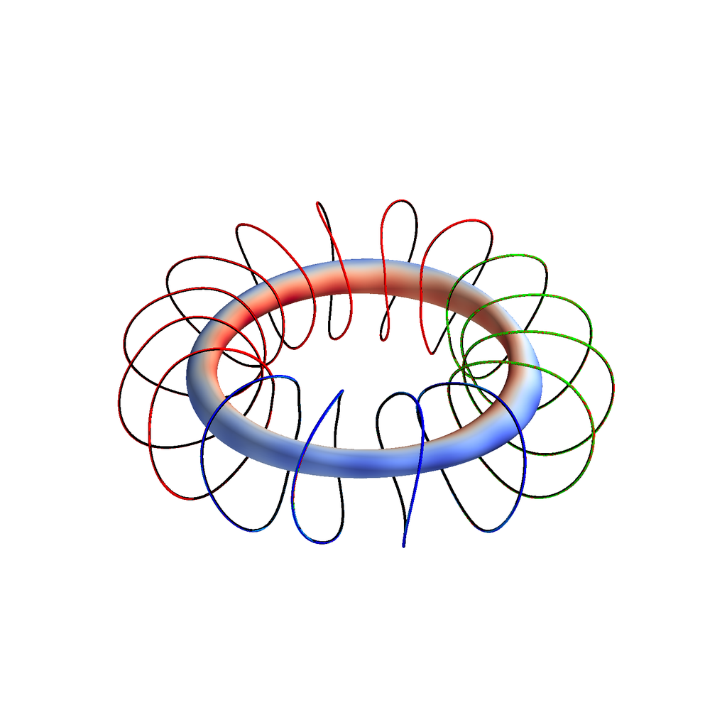

```python
# different coils are plot in different colors
mlab.init_notebook('png')
fig = mlab.figure(size=[1600,1600])
plot_hdf5_surface(master, 'Bmod')
plot_coils(master_coils, color=(0.0, 0.0, 0.0))
plot_coils(develop_coils, color=(0.5, 0.5, 0.5))
plot_coils(full_coils, color=(1.0, 0.0, 0.0))
plot_coils(half_coils, color=(0.0, 1.0, 0.0))
plot_coils(quarter_coils, color=(0.0, 0.0, 1.0))
plot_coils(speed_coils, color=(0.0, 0.5, 1.0))
fig
```

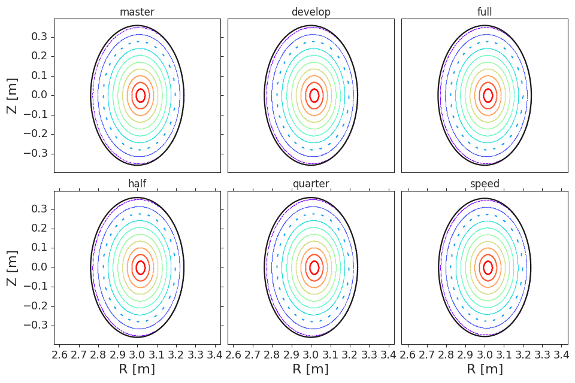

```
read 4 Fourier harmonics for plasma boundary and 0 for Bn distribution in plasma.boundary.
read 4 Fourier harmonics for plasma boundary and 0 for Bn distribution in plasma.boundary.
read 4 Fourier harmonics for plasma boundary and 0 for Bn distribution in plasma.boundary.
read 4 Fourier harmonics for plasma boundary and 0 for Bn distribution in plasma.boundary.
read 4 Fourier harmonics for plasma boundary and 0 for Bn distribution in plasma.boundary.
read 4 Fourier harmonics for plasma boundary and 0 for Bn distribution in plasma.boundary.
```

```python
hdf5s = [master, develop, full, half, quarter, speed]
label = ['master', 'develop', 'full', 'half', 'quarter', 'speed']
f, axes = plt.subplots(2, 3, figsize=[12,8])
for i, ax in enumerate(axes.ravel()):
    plt.sca(ax)
    plot_plasma_boundary('plasma.boundary', color='k')
    plot_focus_poincare(hdf5s[i])
    ax.set_title(label[i], size=15)
    if i<3:
        ax.set_xlabel('')
        ax.set_xticks([])
    if i!=0 and i!=3:
        ax.set_ylabel('')
        ax.set_yticks([])
plt.tight_layout()
```